# Kostenoffenlegung als Wettbewerbsvorteil

Chancen und Potenziale der Kostentransparenz

# Motivation

Die Untersuchung von Kostentransparenz ist aus ökonomischer Sicht besonders spannend, da sie Einblicke in das Zusammenspiel von Marktverhalten, Preiswahrnehmung und Konsumentenvertrauen ermöglicht. In klassischen Märkten gilt Information als asymmetrisch verteilt - insbesondere Kostenstrukturen bleiben für Konsument:innen meist verborgen. Wenn Unternehmen jedoch freiwillig ihre Produktionskosten offenlegen, entsteht eine neue Form der Marktkommunikation, die sowohl auf das Kaufverhalten als auch auf die Markenbindung Einfluss nehmen kann.

In diesem Projekt beschäftigen Sie sich mit der ökonomischen Wirkung unterschiedlicher Formen von Kostentransparenz, darunter produktbezogene Einzelkosten-Offenlegung im Point-of-Sale oder auch verbal vermittelte Transparenz in Kombination mit Vertrauensmessung. Ziel ist es, zu untersuchen, wie sich diese Varianten auf Zahlungsbereitschaft, Vertrauen und wahrgenommene Preisfairness auswirken.

Kern dieser Ausarbeitung ist die Frage, inwiefern Kostentransparenz eine rationale Kaufentscheidung unterstützt oder über emotionale Mechanismen - etwa durch erhöhte Markenattraktivität - wirkt. Für die Analyse greifen Sie auf ein breites Methodenrepertoire zurück, das ökonomische Modellierung mit experimenteller Verhaltensforschung verbindet, und leisten so einen Beitrag zum besseren Verständnis moderner Konsumentenentscheidungen in transparenten Märkten. Für ihre Analyse verwenden Sie die Daten der folgenden Ausarbeitung:

**Mohan, B., Buell, R. W., & John, L. K. (2020). Lifting the veil: The benefits of cost transparency. Marketing Science, 39(6), 1105-1121.**

# Aufbau der Studie

1. Lesen Sie sich den folgenden Text zum Hintergrund und Aufbau der Studie durch und beantworten Sie nachfolgende Fragen dazu:

Der Ausgangspunkt der betrachteten Untersuchung war ein reales Ereignis: Ein Online-Händler stellte im Dezember 2013 ein hochwertiges Lederportemonnaie zum Verkauf. Einige Wochen später wurde auf den Produktseiten eine Infografik zur Kostenzusammensetzung ergänzt, allerdings versehentlich nur bei drei von fünf Farbvarianten. Obwohl der Händler diesen Fehler nicht beabsichtigte, entstand daraus ein sogenanntes natürliches Experiment, also eine reale Vergleichssituation mit kontrollierbaren Unterschieden. Die Verkäufe konnten analysiert werden, um zu überprüfen, ob die Offenlegung der Produktionskosten einen Einfluss auf das Kaufverhalten hatte.

Dieses natürliche Experiment lieferte erste Hinweise darauf, dass Kostentransparenz wirkt - und war damit die Basis für zwei gezielte Experimente im Labor, die Sie sich in diesem Projekt genauer anschauen sollen. Beide Laborexperimente knüpfen an die reale Ausgangslage an - gehen aber unterschiedliche Forschungsfragen an:

Experiment 1: In einem realitätsnahen Online-Setting wurde untersucht, ob Konsument:innen anders entscheiden, wenn sie Informationen zu Produktionskosten sehen. Hierbei sahen die Teilnehmer:innen eine Produktseite für einen Rucksack von Everlane - entweder mit oder ohne Kostenaufstellung (vgl. Abbildung 1: Kostentransparenz Infografik im Anhang). Zusätzlich wurde ein Vergleichsprodukt von J. Crew gezeigt (ohne Hinweise zur Kostenzusammensetzung). Die Teilnehmer:innen mussten entscheiden, von welchem Anbieter sie lieber einen Gutschein erhalten würden. Das Ziel der Forscher war es zu messen, ob Konsument:innen bei mehr Transparenz auch eher kaufen, folglich sich für diesen Gutschein entscheiden.

Experiment 2: Nachdem Experiment 1 zeigte, dass es einen Effekt der Kostentransparenz gibt, stellt sich die psychologische Anschlussfrage, warum es diesen Effekt gibt und wie dieser festzumachen ist. So sahen die Teilnehmer:innen im 2. Experiment ein fiktives Produkt - eine Schokoladentafel. In der Kontrollgruppe wurden nur übliche Produktinfos gezeigt. In der Treatmentgruppe gab es zusätzlich eine detaillierte Kostenaufstellung (vgl. Abbildung 2: Design der Schokoladenverpackung ohne und mit Kostentransparenz im Anhang). Im Anschluss wurden Vertrauen in die Marke und Kaufbereitschaft durch einen Fragebogen abgefragt. So sollte herausgefunden werden, ob Vertrauen der zentrale psychologische Mechanismus für die Kaufentscheidung der Kund:innen ist.

Beantworten Sie nun folgende Fragen:

1. Welches reale Ereignis war der Auslöser der Forschung?
2. Welche konkrete Verhaltensfrage steht im Mittelpunkt von Experiment 1 - Was wollten die Forscher:innen direkt am Kaufverhalten testen?
3. Welcher psychologische Faktor steht im Zentrum von Experiment 2 - und wie hängt er mit dem Kaufverhalten zusammen?

**a)** Ein Online-Händler zeigte 2013 versehentlich nur bei einigen Farbvarianten eines Portemonnaies eine Infografik zur Kostenzusammensetzung. Dieses Versehen schuf ein natürliches Experiment zur Wirkung von Kostentransparenz.

**b)** Die Forscher wollten testen, ob Konsumenten sich häufiger für ein Produkt entscheiden, wenn Produktionskosten offengelegt werden – gemessen an der Wahl eines Gutscheins für ein transparentes vs. nicht transparentes Produkt.

**c)** Zentraler psychologischer Faktor ist Vertrauen. Die Studie prüft, ob Kostentransparenz das Vertrauen in eine Marke erhöht, und dieses Vertrauen wiederum die Kaufbereitschaft steigert.

Nachdem Sie nun die grundlegende Forschungsidee und Zielsetzung der beiden Experimente kennengelernt haben, befassen wir uns im nächsten Schritt vertiefend mit Experiment 1. Ziel ist es, den genauen Aufbau, sowie das konkrete Verhalten der Teilnehmer:innen besser zu verstehen.

2. Lesen Sie sich den folgenden Text zum Aufbau des ersten Experiments durch und beantworten Sie anschließend Fragen dazu:

Cost transparency refers to the disclosure of the costs to produce a good or provide a service. Although cost transparency is a strategy traditionally employed in the context of supplier-firm relationships, wherein the two-way sharing of cost information between parties facilitates collaboration on cost reduction measures, we investigate its effects within the context of consumer-firm relationships. Information on the costs associated with providing goods and services is rarely shared with consumers, but we provide evidence of when and why voluntarily doing so can increase consumers’ purchase interest. Specifically, building on the psychology of disclosure and trust, we posit that cost transparency, insofar as it represents an act of intimate disclosure, fosters trust. In turn, we propose that this heightened trust increases consumers’ willingness to purchase from the transparent firm. In the sections that follow, we discuss our central predictions and highlight alternative accounts. Then, we present experiments, conducted in the lab and in the field, that document the main effects of cost transparency, its underlying psychological drivers, and conditions that moderate its effects.

This first experiment explores how cost transparency influences consumer preferences in an online shopping context. The study was designed as a between-subjects randomized experiment using an incentive-compatible setup, meaning participants made real choices with the possibility of receiving a tangible reward. A total of 509 U.S.-based participants were recruited through Amazon Mechanical Turk (MTurk). Each participant was randomly assigned to one of two experimental conditions:

- Cost Transparency Condition: Participants were shown a simulated product page for a backpack sold by the retailer Everlane. This page included a cost breakdown infographic, listing the production costs such as materials, labor, transport, and duties, with a clearly stated total cost.
- Control Condition: Participants saw the same backpack from Everlane but without any cost information. In both conditions, participants also saw a comparable backpack from J. Crew, which does not practice cost transparency.

Participants were instructed to view both product pages and then asked which company they would prefer to receive a $50 gift card from. Their response served as the main behavioral outcome, representing a choice between the transparent vs. non-transparent retailer. To ensure accurate interpretation of the presented information, a comprehension check followed the main choice question. Participants were also asked for demographic information such as age, gender, income, and education, to allow for potential control variables in later analysis.

Beantworten Sie nun folgende Fragen:

1. Wie viele Personen nahmen final an dem Experiment teil?
2. Worin bestand der Unterschied zwischen der Transparenzbedingung und der Kontrollbedingung?
3. Welche Anreizstruktur wurde verwendet, um die Entscheidung der Teilnehmenden realistisch zu gestalten?
4. Wie unterschieden sich die beiden gezeigten Onlinehändler im Experiment?
5. Warum wurde im Anschluss an die Entscheidungsfrage ein Verständnischeck durchgeführt?
6. In der Beschreibung des Experiments wird von “between-subjects randomized experiment using an incentive-compatible setup” gesprochen. Was versteht man hierunter im Detail?

*Hinweis:* Für die Beantwortung der letzten Frage können Sie [diesen Artikel (Seite 1-5)](https://www.researchgate.net/publication/268269783_Incentives_in_Experiments_A_Theoretical_Analysis) als Grundlage verwenden.

**a) Wie viele Personen nahmen final an dem Experiment teil?** Es nahmen 509 US-amerikanische Personen an dem Experiment teil.

**b) Worin bestand der Unterschied zwischen der Transparenzbedingung und der Kontrollbedingung?** In der Transparenzbedingung sahen die Teilnehmer eine Produktseite mit einer Infografik zur Kostenzusammensetzung des Rucksacks. In der Kontrollbedingung wurde derselbe Rucksack gezeigt, aber ohne diese Kosteninformationen.

**C) Welche Anreizstruktur wurde verwendet, um die Entscheidung der Teilnehmenden realistisch zu gestalten?** Die Teilnehmer trafen eine Entscheidung mit der realen Möglichkeit, eine 50-Dollar-Geschenkkarte des gewählten Unternehmens zu erhalten.

**d) Wie unterschieden sich die beiden gezeigten Onlinehändler im Experiment?** Der Händler Everlane zeigte in einer Versuchsbedingung Kostentransparenz (mit Infografik), in der Kontrollbedingung jedoch nicht. Der Händler J. Crew zeigte in beiden Bedingungen keine Kostentransparenz und diente als Vergleichsanbieter.

**e) Warum wurde im Anschluss an die Entscheidungsfrage ein Verständnischeck durchgeführt?** Der Verständnischeck wurde durchgeführt, um sicherzustellen, dass die Teilnehmer die angezeigten Informationen korrekt verstanden hatten. So konnte ausgeschlossen werden, dass Unterschiede in der Entscheidung auf Missverständnisse oder fehlende Aufmerksamkeit zurückzuführen waren.

**f) In der Beschreibung des Experiments wird von “between-subjects randomized experiment using an incentive-compatible setup” gesprochen. Was versteht man hierunter im Detail?** Unter “Between-subjects design” versteht man, dass jede der 509 Versuchspersonen nur einer der beiden Bedingungen zufällig zugewiesen wird (Transparenz oder Kontrolle). Es handelt sich somit um getrennte Gruppen, die unabhängig voneinander getestet werden. “Randomized” bedeutet, dass die Versuchspersonen zu den Bedingungen zufällig zugeteilt werden, wodurch systematische Verzerrungen reduziert und die interne Validität des Experiments erhöht werden. Unter “Incentive-compatible setup” ist zu verstehen, dass die Entscheidungsaufgabe realitätsnah ist, da die Wahl echte Konsequenzen hat. Hier haben die Versuchspersonen eine tatsächliche Chance auf eine 50-Dollar-Geschenkkarte. Laut dem Artikel führt dies dazu, dass die Teilnehmer ein Eigeninteresse daran haben, ihre wahren Präferenzen zu zeigen, was wichtig ist, um strategisches Verhalten zu vermeiden.

# Daten

## Datenimport und -aufbereitung

Die Daten, die Sie für die nachfolgenden Analysen verwenden, wurden zu Replikationszwecken von den Autoren der Studie zur Verfügung gestellt und können hier heruntergeladen werden:

**Bhavya Mohan, Ryan W. Buell, Leslie K. John (2020) Lifting the Veil: The Benefits of Cost Transparency. Marketing Science 39(6):1105-1121. mksc.2019.1200.sm1.pdf**

Wir haben die Daten für Sie heruntergeladen und im Unterordner mit dem Namen `Daten` bereitgestellt. Für ihre Analyse werden die Dateien `Experiment1.csv` und `Experiment2.csv` genutzt. Für die Zusatzaufgabe ist die Datei `Experiment3.csv` relevant.

3. Lesen Sie den Datensatz `Experiment1.csv` aus dem Unterordner `Daten` in R ein. Nennen Sie den Datensatz in R `daten_exp1`.

Im Datensatz sind unterschiedliche Variablen enthalten. Weiterhin habe wir Ihnen ein Readme mit den Beschreibungen zu den Variablen bereitgestellt. Nutzen Sie dieses und den Text aus Aufgabe 2, um die Variablen zu beschreiben.

**Beschreibung der Variablen:**

In Klammern wird bei diesen Variablen angegeben, wie diese folglich genannt werden. Dies soll einem besseren Verständnis der Variablen dienen:

- treatment (Kostentransparenz): Gibt an, ob die Teilnehmer die kostentransparente Website gesehen haben (1 = Kosten-Transparenz, 0 = Kontrolle).
- everlane (Everlane-Geschenkkarte): Gibt die Wahl der Geschenkkarte an (1 = Wahl der Everlane-Geschenkkarte, 0 = Wahl der J Crew-Geschenkkarte).
- passed (Verständnistest): Gibt an, ob die Teilnehmer den Verständnis-Test bestanden haben (1 = Test bestanden, 0 = Test nicht bestanden).
- email_provided (E-Mail-Adresse): Gibt an, ob die Teilnehmer eine E-Mail-Adresse angegeben haben, an die die Geschenkkarte gesendet werden kann (1 = E-Mail-Adresse angegeben, 0 = Keine E-Mail-Adresse angegeben).
- female (Weiblich): Teilnehmer haben optional ihr Geschlecht angegeben (1 = weiblich, 0 = männlich).
- age (Alter): Teilnehmer haben optional ihr Alter angegeben (offene Antwort).
- educ (Bildung): Teilnehmer haben optional ihren Bildungsabschluss angegeben (1 = Einige Jahre in der Schule, 2 = Schulabschluss, 3 = Einige Jahre College, 4 = Hochschulabschluss, 5 = Postgradual/beruflich).
- income (Einkommen): Teilnehmer haben optional ihr monatliches Einkommensniveau angegeben (1 = Keines, 2 = Unter 60 Dollar, 3 = 60-499 Dollar, 4 = 500-999 Dollar, 5 = 1.000-1.999 Dollar, 6 = 2.000-2.999 Dollar, 7 = 3.000-3.999 Dollar, 8 = 4.000-4.999 Dollar, 9 = 5.000-7.499 Dollar, 10 = 7.500-9.999 Dollar, 11 = Über 10.000 Dollar, 12 = Weiß nicht/Bevorzuge keine Antwort).

## Deskriptive Analyse

Sie sollten sich im ersten Schritt einen Überblick über ihre Daten verschaffen.

4. Auf Basis des Datensatzes `daten_exp1` aus Aufgabe 3 erstellen Sie eine deskriptive Tabelle mit der Anzahl an Beobachtungen, den Mittelwerten, der Standardabweichungen, dem Median, sowie den Minima und Maxima für alle in `daten_exp1` enthaltenen Variablen.

Beschreiben und interpretieren Sie ihre Tabelle. Gehen Sie insbesondere auf die Verteilungen der einzelnen Variablen ein. Was fällt hier besonders auf.

Deskriptive Statistik

| Variable | Kennzahlen Anzahl | Kennzahlen Mittelwert | Kennzahlen Standardabweichung | Kennzahlen Median | Kennzahlen Minimum | Kennzahlen Maximum |
| --- | --- | --- | --- | --- | --- | --- |
| Kostentransparenz | 509 | 0.50 | 0.50 | 0 | 0 | 1 |
| Everlane-Geschenkkarte | 509 | 0.63 | 0.48 | 1 | 0 | 1 |
| Verständnistest | 509 | 0.77 | 0.42 | 1 | 0 | 1 |
| E-Mail Adresse | 509 | 0.56 | 0.50 | 1 | 0 | 1 |
| Weiblich | 509 | 0.49 | 0.50 | 0 | 0 | 1 |
| Alter | 505 | 37.59 | 11.74 | 35 | 18 | 81 |
| Bildung | 505 | 3.76 | 0.84 | 4 | 1 | 5 |
| Einkommen | 505 | 7.58 | 2.43 | 8 | 1 | 12 |

**Beschreibung:**

Die deskriptive Statistik umfasst acht Variablen des Datensatzes daten_exp1, darunter sowohl binäre als auch metrische Merkmale. Für jede Variable wurden die Anzahl der gültigen Beobachtungen, der Mittelwert, die Standardabweichung, der Median sowie die Minimal- und Maximalwerte berechnet.

Die binären Variablen (Kostentransparenz, Wahl der Everlane-Geschenkkarte, Verständnistest, E-Mail-Adresse, Weiblich) sind jeweils zwischen 0 und 1 kodiert. Für alle fünf liegen vollständige Beobachtungszahlen von jeweils 509 vor. Die Mittelwerte reichen dabei von 0,49 (Weiblich) bis 0,77 (Verständnistest), was auf unterschiedliche Häufigkeiten der jeweils positiven Ausprägung hinweist.

Die metrischen Variablen Alter, Bildung und Einkommen weisen jeweils 505 gültige Beobachtungen auf. Das durchschnittliche Alter der Teilnehmenden beträgt 37,59 Jahre bei einer Standardabweichung von 11,74 Jahren. Das Alter liegt zwischen 18 und 81 Jahren. Der Mittelwert der Bildung beträgt 3,76 (d.h. zwischen einige Jahre College und Hochschulabschluss), während das durchschnittliche Einkommen bei 7,58 (d.h. zwischen 3000 und 5000 Dollar) liegt.

**Interpretation:**

Die gleichmäßige Verteilung in der Kostentransparenz-Variable (Mittelwert = 0,50) bestätigt die erfolgreiche Randomisierung der Teilnehmenden auf Kontroll- und Experimentalgruppe – ein wichtiges Kriterium für die interne Validität des Experiments. Der Mittelwert von 0,63 bei der Variable Everlane-Geschenkkarte zeigt, dass sich ein Großteil der Teilnehmenden für einen Gutschein von Everlane entschied. Dies legt nahe, dass die Transparenz in der Kostenaufstellung einen positiven Einfluss auf die wahrgenommene Attraktivität dieses Anbieters hatte.

Mit 77% korrekt beantworteten Verständnisfragen (Verständnistest) kann von einer insgesamt guten Datenqualität ausgegangen werden. Ebenso zeigt die Bereitschaft von 56% der Befragten, ihre E-Mail-Adresse anzugeben, ein moderates Maß an Vertrauen oder Engagement. Die Geschlechterverteilung ist mit einem Anteil von 49% weiblich sehr ausgeglichen. Das Alter der Befragten ist breit gestreut und weist mit einem Median von 35 Jahren auf eine relativ junge bis mittelalte Stichprobe hin. Die Variablen Bildung und Einkommen deuten auf ein eher bildungs- und einkommensstarkes Sample hin.

Insgesamt liefert die Tabelle sowohl Hinweise auf die Qualität der Stichprobe als auch erste Indizien dafür, dass Kostentransparenz das Konsumentenverhalten messbar beeinflussen kann, insbesondere in Bezug auf die Präferenz für einen Anbieter.

5. Im Datensatz `daten_exp1` gibt es Variablen für die keine Beobachtungen vorhanden sind.
- Gegeben ihrer Variablenbeschreibung in Aufgabe 3:
  - Macht es Sinn die Beobachtungen aus dem Datensatz zu entfernen, wenn für bestimmte Variablen keine Werte vorhanden sind?
  - Wenn ja, warum?
  - Wie viele Beobachtungen entfernen Sie dadurch aus ihrem Datensatz?

Entfernen Sie nun alle Beobachtungen (d.h. gesamte Zeilen aus dem Datensatz), bei denen für mindestens eine der erhobenen Variablen kein Wert vorliegt, da unvollständige Daten für die Analyse nicht berücksichtigt werden sollen.

Untersuchen Sie weiterhin, ob sich die Teilnehmer, die die Webseite mit der Kostentransparenz gesehen haben (Treatmentgruppe), systematisch von jenen unterscheiden, die die Kontrollversion gesehen haben. Auch wenn es sich um ein Experiment handelt, bei dem die Zuteilung zu den Gruppen zufällig erfolgt ist, sollten Sie dennoch prüfen, ob es unbeabsichtigte (systematische) Unterschiede zwischen den Gruppen gibt. Erstellen Sie hierfür eine Balancing-Tabelle, in der Sie die Mittelwerte von Alter (age), Geschlecht (female), Einkommensstufe (income) und Bildungsniveau (educ) zwischen den beiden Gruppen vergleichen, die Differenzen berechnen und mithilfe von T-Tests prüfen, ob diese Unterschiede statistisch signifikant sind.

- Beschreiben und interpretieren Sie ihre Tabelle.
  - Was fällt Ihnen in Bezug auf die p-Werte auf?
  - Was müssten Sie bei einer weiteren Regressionsanalyse berücksichtigen?

*Hinweis:* Die beiden Gruppen, die Sie in der Balancing Tabelle betrachten sollen, können aus den Werten (1 und 0) der Variable `treatment` abgeleitet werden.

Ja, es macht Sinn, Beobachtungen mit fehlenden Werten zu entfernen. Unvollständige Beobachtungen können zu verzerrten Ergebnissen führen, wenn die Daten nicht zufällig fehlen und die Vergleichbarkeit zwischen Gruppen (Treatment vs. Kontrolle) erschweren. Es fehlen hier mit Blick auf den Datensatz in lediglich vier Beobachtungen Werte - somit ist der Verlust an Daten minimal und besonders für die Erstellung einer Balancing-Tabelle oder zur Durchführung von Regressionsanalysen ist es wichtig, nur vollständige Daten zu betrachten, um sie sauber interpretieren zu können. Im Folgenden werden also vier Beobachtungen aus dem Datensatz entfernt.

Balancing-Tabelle zwischen Treatment- und Kontrollgruppe

| Variable | Mittelwert Kontrollgruppe | Mittelwert Treatmentgruppe | Differenz | p-Wert |
| --- | --- | --- | --- | --- |
| Alter | 37.91 | 37.27 | -0.64 | 0.54 |
| Weiblich | 0.49 | 0.49 | 0.00 | 0.96 |
| Einkommen | 7.40 | 7.76 | 0.36 | 0.10 |
| Bildung | 3.73 | 3.79 | 0.06 | 0.42 |

**Beschreibung:**

Die Balancing-Tabelle zeigt einen Vergleich von Alter, Geschlecht, Einkommen und Bildung zwischen der Kontrollgruppe und der Treatmentgruppe des Experiments. Ziel ist es zu prüfen, ob sich die beiden Gruppen vor Beginn der Behandlung systematisch unterscheiden. Dabei werden die Mittelwerte der untersuchten Merkmale verglichen und Differenzen berechnet. Mithilfe von T-Tests wird dann statistisch überprüft, ob diese Unterschiede signifikant sind. Ein Unterschied ist dabei signifikant, wenn der p-Wert kleiner als ein vorher festgelegtes Signifikanzniveau ist, überlicherweise 0,01 oder 0.05. Diese Werte würden bedeuten, dass die Unterschiede sehr wahrscheinlich nicht durch Zufall zustande gekommen sind. Ist der p-Wert hingegen größer, spricht man von nicht signifikant. Das bedeutet wiederum, dass es keine ausreichenden Belege für einen echten Unterschied zwischen den Gruppen gibt, und die Abweichungen zufällig sein können. Wir erhoffen uns hier also hohe p-Werte, sodass die Differenzen nicht signifikant sind.

Schauen wir uns die Ergebnisse genauer an:

- **Alter:** Der durchschnittliche Altersuntesrchied zwischen Kontroll- und Treatmentgruppe beträgt nur -0.64 Jahre, was statistisch nicht signifikant ist (p-Wert = 0.54). Die beiden Gruppen sind somit in Bezug auf das Alter gut ausbalanciert.
- **Geschlecht:** Der Anteil weiblicher Teilnehmer ist in beiden Gruppen mit je 49% identisch, wodurch sich eine Differenz von 0 ergibt. Auch hier gibt es keine systematischen Unterschiede, wie sich durch den hohen p-Wert von 0,96 zeigt.
- **Einkommen:** Das durchschnittliche Einkommen ist in der Treatmentgruppe um 0.36 höher, jedoch ist der Unterschied nicht signifikant (p-Wert = 0.1). Dies deutet auf eine leicht unterschiedliche, aber dennoch akzeptable Verteilung hin.
- **Bildungsniveau:** Der Unterschied im Bildungsniveau beträgt lediglich 0.06 Punkte und ist ebenfalls nicht signifikant (p-Wert = 0.42).

**Interpretation:**

Alle p-Werte liegen somit deutlich über dem üblichen Signifikanzniveau von 0.01 oder 0.05, was bedeutet, dass keine statistisch signifikanten Unterschiede in den demografischen Variablen zwischen Kontroll- und Treatmentgruppe vorliegen. Die Randomisierung hat somit gut funktioniert und die Gruppen sind hinsichtlich Alter, Geschlecht, Einkommen und Bildung vergleichbar.

Bei einer weiteren Regressionsanalyse muss trotz der nicht signifikanten Unterschiede beachtet werden, dass auch diese theoretisch die Ergebnisse beeinflussen können. Um die Präzision der Schätzungen zu erhöhen und mögliche Rest-Confounder auszuschließen, ist es sinnvoll, demografische Variablen wie Alter, Geschlecht, Einkommen und Bildung als Kontrollvariablen in Regressionsmodellen mit einzubeziehen.

Nachdem Sie sich in den vorangegangenen Aufgaben bereits mit der Verteilung der Daten und den Unterschieden zwischen den einzelnen Gruppen auseinandergesetzt haben, geht es nun um eine explorative Betrachtung von Zusammenhängen zwischen den zentralen Variablen im Datensatz.

6. In dieser Aufgabe führen Sie eine Korrelationsanalyse durch, um herauszufinden, ob und wie stark einzelne Merkmale - wie Alter, Bildung, Einkommen oder Geschlecht - mit der Treatment-Zugehörigkeit sowie der Entscheidung für die Everlane-Gutscheinkarte zusammenhängen.

Wählen Sie die folgenden Variablen aus dem Datensatz `daten_exp1` aus:

- treatment
- everlane
- age
- income
- educ
- female

Berechnen Sie die Korrelationsmatrix dieser Variablen. Visualisieren Sie die Matrix (als Tabelle oder Grafik), in der die Korrelationskoeffizienten und deren Stärke farblich dargestellt sind.

Beschreiben und interpretieren Sie ihre Tabelle/Grafik. Gehen Sie hierbei auch auf folgende Fragen ein:

- Was bedeutet ein positiver Zusammenhang (Korrelation) zwischen `treatment` und `everlane` im Kontext der Hypothese, dass Kostentransparenz die Entscheidung für Everlane beeinflusst?
- Warum kann eine Korrelation auf einen Zusammenhang hinweisen, aber nicht ausreichen, um einen kausalen Effekt nachzuweisen - selbst wenn wir wissen, dass `treatment` im Experiment zufällig zugewiesen wurde?
- Was nützt ihnen eine Korrelationsmatrix im Vergleich zu einem einfachen Mittelwertvergleich zwischen den Gruppen?

*Hinweis:* Für die Darstellung der Korrelationsmatrix können Sie z.B. das Paket corrplot verwenden.

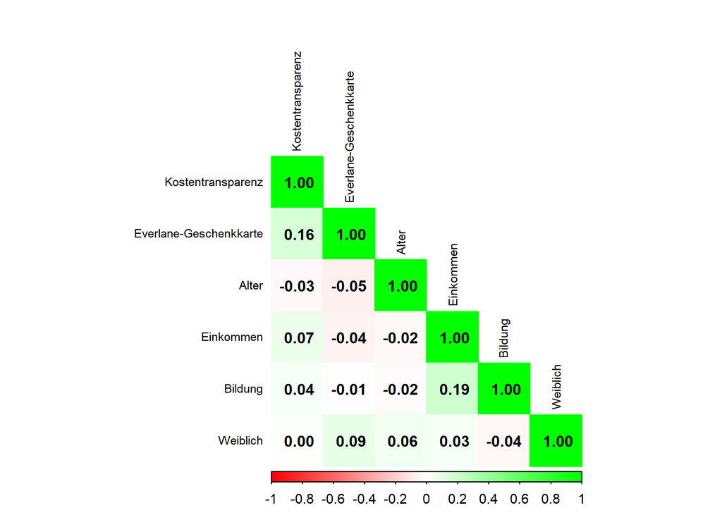

**Interpretation:**

Der positive Korrelationskoeffizient von 0,16 zwischen den Variablen Kostentransparenz und Everlane-Geschenkkarte bedeutet, dass Personen in der Treatmentgruppe, also Personen die auch Infos über die Kostenstruktur haben, häufiger die Everlane-Geschenkkarte gewählt haben. Das spricht für die Hypothese, dass Kostentransparenz das Vertrauen und damit die Kaufbereitschaft erhöht. Allerdings reicht eine Korrelation nicht aus, um Kausalität zu belegen. Korrelationen zeigen nur einen statistischen Zusammenhang, aber nicht, was Ursache und was Wirkung ist. Es kann auch gut sein, dass andere unbeachtete Merkmale mit der Wahl der Everlane-Geschenkkarte korrelieren. Die anderen Variablen haben meist geringe Korrelationen miteinander. Auffällig ist die hohe Korrelation zwischen Bildung und Einkommen von 0.19 - diese Korrelation ist auch naheliegend, da mehr Bildung meistens mit besser bezahlten Berufen einhergeht.

Eine Korrelationsmatrix bietet gegenüber einem Mittelwertvergleich den Vorteil, dass man alle paarweisen Zusammenhänge gleichzeitig betrachten kann. Mittelwertvergleiche hingegen zeigen nur Unterschiede zwischen zwei Gruppen in Bezug auf eine Zielvariable, nicht aber Zusammenhänge unter den erklärenden Variablen selbst.

7. In Aufgabe 1 und 2 haben Sie gelesen, dass den Teilnehmern ein Angebot gemacht wurde, eine Everlane-Gutscheinkarte anzunehmen. Erzeugen Sie eine geeignete Grafik, die den durchschnittlichen Anteil der angenommenen Angebote (d.h. den Anteil, in dem die Everlane-Karte gewählt wurde) getrennt für die Treatment- und die Kontrollgruppe darstellt. Fügen Sie in der Grafik zusätzlich den Standardfehler der Mittelwerte ein. Führen Sie einen T-Test durch, um zu prüfen, ob der Unterschied im Mittelwert zwischen der Treatment- und Kontrollgruppe statistisch signifikant ist, und geben Sie das Testergebnis (den p-Wert) deutlich sichtbar in der Grafik an. Achten Sie dabei auf eine verständliche Beschriftung Ihrer Grafik sowie auf einen aussagekräftigen Titel.

Beschreiben und interpretieren Sie ihre Grafik. Gehen Sie insbesondere auf folgende Fragen ein:

- Welche Aussage lässt sich auf Basis des durchgeführten T-Tests treffen?
- Welche der in den vorherigen Aufgaben (vgl. Aufgabe 4 und 5) analysierten Faktoren könnten dazu beigetragen haben, dass ein signifikanter Unterschied im Anteil angenommener Everlane-Angebote zwischen Treatment- und Kontrollgruppe beobachtet wird?

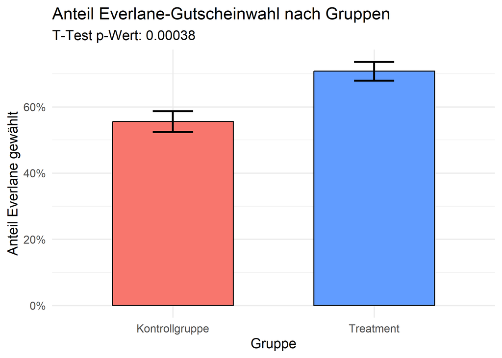

**Beschreibung:**

Die Grafik zeigt für die Kontroll- und Treatmentgruppe getrennt den prozentualen Anteil an Personen, welche die Everlane-Geschenkkarte gewählt haben. Der Fehlerbalken gibt den Standardfehler der Mittelwerte an und der p-Wert des T-Tests, welcher direkt unter dem Titel steht, gibt an, ob der Unterschied statistisch signifikant ist. Es fällt auf, dass mit etwa 71% ein deutlich höherer Anteil der Personen in der Treatmentgruppe die Everlane-Gutscheinkarte gewählt haben, verglichen mit der Kontrollgruppe mit etwa 55%. Der T-Test prüft, ob der beobachtete Unterschied im Mittelwert der Gutscheinwahl zwischen Treatment- und Kontrollgruppe rein zufällig entstanden sein könnte. Der p-Wert liegt hier bei 0,0004 und ist somit auf dem 1%-Niveau signifikant. Man kann daher mit hoher Wahrscheinlichkeit ausschließen, dass dieser Unterschied auf Zufall beruht.

**Interpretation:**

Auf Basis des T-Tests lässt sich feststellen, dass Teilnehmende in der Treatmentgruppe signifikant häufiger die Everlane-Geschenkkarte wählten als Teilnehmende in der Kontrollgruppe. Dies deutet auf einen kausalen Effekt der Kostentransparenz auf die Wahlentscheidung hin. Die Grundlage für diese Interpretation bildet die Randomisierung, durch die systematische Unterschiede zwischen den Gruppen ausgeschlossen werden sollen. Die Balancing-Analyse in Aufgabe 5 zeigt, dass es keine signifikanten Unterschiede in den zentralen demografischen Merkmalen (Alter, Geschlecht, Einkommen und Bildung) zwischen Treatment- und Kontrollgruppe gibt. Dies spricht für eine vergleichbare Ausgangslage beider Gruppen und erhöht die interne Validität der Ergebnisse.

Gleichzeitig gilt aber: Kein signifikanter Unterschied bedeutet nicht automatisch keinen Einfluss. Kleinere, statistisch nicht signifikante Differenzen – etwa beim Einkommen – könnten theoretisch dennoch in Kombination mit dem Treatment die Ergebnisse leicht beeinflussen. Solche Effekte lassen sich durch die zusätzliche Kontrolle dieser Variablen in Regressionsmodellen besser adressieren.

Insgesamt sprechen die Ergebnisse dafür, dass Kostentransparenz das Vertrauen der Konsumenten stärkt und die wahrgenommene Glaubwürdigkeit des Unternehmens positiv beeinflusst. Dies scheint wiederum die Wahrscheinlichkeit zu erhöhen, dass sich Konsumenten für Angebote eines solchen Unternehmens entscheiden.

In den vorherigen Aufgaben des Projekts haben Sie sich bereits intensiv mit dem Experiment 1 auseinandergesetzt, in dem untersucht wurde, ob und wie die Offenlegung von Produktionskosten - also Kostentransparenz - das Konsumverhalten beeinflusst. Es wurde gezeigt: Wenn Konsument:innen transparent mitgeteilt wird, wie sich die Kosten eines Produkts zusammensetzen, steigt ihre Bereitschaft, bei dem entsprechend transparenten Unternehmen einzukaufen.

Diese Ergebnisse legen nahe, dass die Offenlegung sensibler Unternehmensinformationen (wie Produktionskosten) das Vertrauen der Konsument:innen in das Unternehmen stärkt und sie somit eher zu einem Kauf motiviert.

Doch was genau ist der psychologische Mechanismus hinter dieser Wirkung? Ist es tatsächlich das Vertrauen in das Unternehmen, das durch die Offenlegung sensibler Informationen gestärkt wird - und in der Folge die Kaufbereitschaft erhöht?

Um genau diese Frage zu beantworten, führen die Autoren ein weiteres Experiment durch, das den vermuteten psychologischen Vermittlungsmechanismus des Vertrauens genauer untersucht. Dabei wurde geprüft, ob Vertrauen tatsächlich als Mediator zwischen Kostentransparenz und Kaufinteresse wirkt. Hierzu wurde ein kontrolliertes Online-Experiment mit über 600 Teilnehmer:innen durchgeführt. Die Teilnehmenden wurden zufällig einer von zwei Bedingungen zugewiesen:

- In der **Kostentransparenz-Gruppe** (Treatment) wurde zusätzlich eine detaillierte Aufschlüsselung der Produktionskosten angegeben. Diese beinhaltete die einzelnen Kostenkomponenten (z.B. Kakaobutter, Verpackung, Arbeitskosten) sowie die Gesamtkosten der Schokoladentafel (vgl. Abbildung 2 im Anhang).
- In der **Kontrollgruppe** sahen die Teilnehmer die Verpackung einer fiktiven Schokoladenmarke namens „Cocoa Passion“. Diese enthielt nur die üblichen Informationen wie Zutaten, Nährwerte und eine Produktbeschreibung.

Ziel war es, zu untersuchen, ob die Offenlegung dieser sensiblen Informationen das Vertrauen der Konsument:innen in die Marke stärkt - und ob dieses Vertrauen wiederum die Kaufbereitschaft beeinflusst. In den nächsten Aufgaben werden Sie diese Studie genauer beleuchten, analysieren und evaluieren, ob sich die Hypothese empirisch bestätigen lässt.

8. Lesen Sie die Daten des zweiten Experiments (`Experiment2.csv`) in R ein. Nennen Sie den Datensatz `daten_exp2`. Benennen Sie die Variable `cost` in `treatment` um.

Untersuchen Sie, ob sich die Teilnehmer, die die Verpackung mit transparenter Kosteninformation gesehen haben, systematisch von jenen unterscheiden, die nur die Kontrollversion gesehen haben.

Erstellen Sie hierfür eine Balancing-Tabelle, in der Sie die Mittelwerte von Alter (age), Geschlecht (female), Einkommensstufe (income), Bildungsniveau (educ), Vertrauen (trust) und Kaufbereitschaft (wtb) zwischen den beiden Gruppen vergleichen, die Differenzen berechnen und mithilfe von T-Tests prüfen, ob diese Unterschiede statistisch signifikant sind. Nehmen Sie weiterhin die Anzahl an Beobachtungen in der Treatment- und in der Kontrollgruppe in ihre Tabelle mit auf.

Beschreiben und interpretieren Sie ihre Tabelle. Gehen Sie dabei insbesondere auf folgende Fragen ein:

- Was versteht man unter der Variable `wtb`?
- Was lässt sich aus der Größen der Stichprobe ableiten?
- Wo könnte es bei einer Regression (oder einem sonstigen Vergleich der Gruppen) zu Problemen kommen und was wären mögliche Auswirkungen?

*Hinweis:* Für die Beschreibung der `wtb` können Sie das bereitgestellte Readme nutzen.

Balancing-Tabelle zwischen Treatment- und Kontrollgruppe

| Variable | Mittelwert Kontrollgruppe | Mittelwert Treatmentgruppe | Differenz | p‑Wert |
| --- | --- | --- | --- | --- |
| Alter | 36.28 | 34.06 | -2.22 | 0.02 |
| Weiblich | 0.42 | 0.48 | 0.05 | 0.18 |
| Einkommen | 6.96 | 6.79 | -0.17 | 0.38 |
| Bildung | 3.51 | 3.57 | 0.06 | 0.40 |
| Vertrauen | 4.82 | 5.29 | 0.47 | 0.00 |
| Kaufabsicht | 3.74 | 4.27 | 0.53 | 0.00 |

Anzahl Personen Kontrollgruppe: 301  
Anzahl Personen Treatmentgruppe: 300

**Beschreibung:**

Die Balancing Tabelle vergleicht die Mittelwerte vom Alter, Geschlecht, Einkommen, Bildung, Vertrauen und der Kaufabsicht für zwei Gruppen: zum einen die Kontrollgruppe, welcher keine transparenten Kosteninformationen vorliegen, und der Treatmentgruppe, welcher transparente Kosteninformationen vorliegen. Zusätzlich werden noch die Anzahl der Personen pro Gruppe, die Differenz der Mittelwerte zwischen den Gruppen und die Ergebnisse von T-Tests, also der p-Wert, aufgeführt. Der T-Test dient wieder dazu herauszufinden, ob die Unterschiede zwischen den Gruppen statistisch signifikant sind.

Beide Stichproben haben eine sehr ähnliche Teilnehmerzahl, in der Kontrollgruppe befinden sich 301 Personen, in der Treatmentgruppe 300 Personen. Das spricht für stabile und robuste Schätzungen, die eine gute Vergleichbarkeit der Gruppen zulässt.

Man erkennt, dass die Gruppen bei den Merkmalen Geschlecht, Einkommen und Bildung sehr ähnlich sind. Die p-Werte sind hier > 0.05 und damit ist der Unterschied statistisch nicht signifikant. Beim Alter lässt sich feststellen, dass die Kontrollgruppe im Durchschnitt mit 36,28 Jahren um 2,22 Jahre älter ist, als die Treatmentgruppe. Dieser Unterschied ist auch mit einem p-Wert von 0.02 statistisch signifikant, was bedeutet, dass sich beide Gruppen hinsichtlich des Alters systematisch unterscheiden. Beim Vertrauen und der Kaufabsicht findet man hochsignifikante Unterschiede vor, der p-Wert liegt hier bei 0.00. Kurz zur Variable wtb bzw. Kaufabsicht: Diese gibt die willingness-to-buy an. Hierbei wurden die Teilnehmer gefragt, wenn sie die Möglichkeit hätten, wie wahrscheinlich es dann wäre, dass sie dieses Produkt kaufen würden. Hierbei waren Antwortmöglichkeiten von 1 bis 7 möglich, 1 bedeutet überhaupt nicht, 7 bedeutet sehr wahrscheinlich.

**Interpretation:**

Die Balancing-Tabelle zeigt, dass die Randomisierung hinsichtlich der Variablen Geschlecht, Einkommen und Bildung gut funktioniert hat, da für diese Merkmale keine signifikanten Unterschiede zwischen der Kontroll- und der Treatmentgruppe bestehen. Dies spricht für eine vergleichbare Zusammensetzung der Gruppen in diesen Aspekten und gewährleistet, dass sie sich diesbezüglich nicht systematisch unterscheiden. Im Gegensatz dazu zeigen sich bei Alter, Vertrauen in die Marke („trust“) und Kaufabsicht („wtb“) signifikante Unterschiede zwischen den Gruppen. Die Treatmentgruppe ist im Durchschnitt jünger, zeigt ein höheres Vertrauen und eine größere Kaufabsicht. Diese Unterschiede sind relevant, da Alter und Vertrauen potenziell mit der Reaktion auf das Treatment verknüpft sein können: Jüngere Personen könnten beispielsweise technikaffiner sein oder andere Präferenzen haben, die ihr Entscheidungsverhalten beeinflussen. Ein höheres Vertrauen in die Marke kann die Bereitschaft zum Kauf unabhängig vom Treatment erhöhen. Daher ist es wichtig, diese Variablen als Kontrollvariablen in weitere Analysen einzubeziehen. So kann sichergestellt werden, dass der beobachtete Effekt der Behandlung auf die Kaufentscheidung nicht durch die systematischen Gruppenunterschiede in Alter und Vertrauen verfälscht wird. Die Kaufabsicht hingegen sollte nicht als Kontrollvariable aufgenommen werden, da sie vermutlich das zentrale Outcome darstellt, dessen Beeinflussung durch das Treatment untersucht werden soll.

9. In ihrem Datensatz gibt es einige Beobachtungen ohne vorhandene Werte. Behalten Sie nur die Beobachtungen bei denen vollständige Werte vorliegen. Erzeugen Sie eine geeignete Grafik, welche den durchschnittlichen Anteil der ‘Kaufbereitschaft’ im zweiten Experiment für die Treatment- und Kontrollgruppe darstellt.

Die Grafik soll:

- die Mittelwerte der Kaufbereitschaft für beide Gruppen zeigen,
- die zugehörigen Standardfehler als Fehlerbalken visualisieren und
- das Ergebnis des T-Tests, der die Mittelwertdifferenz prüft, direkt in die Grafik integrieren.

Beschreiben und interpretieren Sie ihre Grafik.

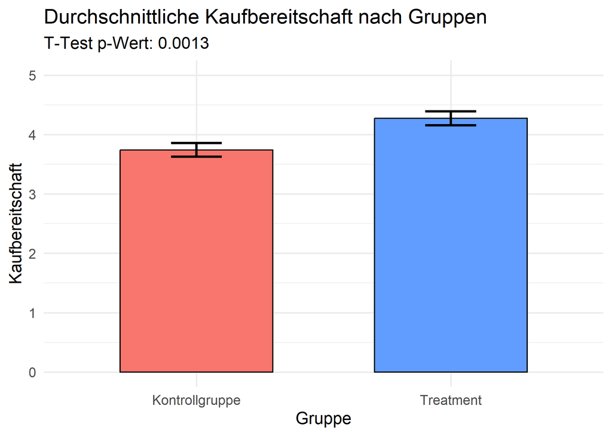

**Beschreibung:**

Es zeigt sich, dass die Kaufbereitschaft in der Treatmentgruppe – also bei den Personen, die eine Verpackung mit transparenter Kostenaufstellung gesehen haben – deutlich höher liegt als in der Kontrollgruppe. Der Mittelwert in der Treatmentgruppe beträgt etwa 4,3, während er in der Kontrollgruppe nur bei rund 3,8 liegt. Diese Differenz ist nicht nur visuell erkennbar, sondern auch statistisch signifikant. Der T-Test ergibt einen p-Wert von 0.0013, was auf ein hohes Maß an statistischer Sicherheit hindeutet (p < 0.01).

**Interpretation:**

Die dargestellte Grafik zeigt, dass die Offenlegung von Produktionskosten – also die transparente Darstellung der Preiszusammensetzung – einen klar positiven Einfluss auf die Kaufbereitschaft hat. Teilnehmende, die zur Treatmentgruppe gehörten und die Verpackung mit Kostentransparenz sahen, zeigten im Durchschnitt eine signifikant höhere Kaufbereitschaft als jene in der Kontrollgruppe, die lediglich Standardinformationen erhielten.

Mit einem durchschnittlichen Wert von etwa 4,3 in der Treatmentgruppe gegenüber 3,8 in der Kontrollgruppe ist der Unterschied zwar auf einer siebenstufigen Skala inhaltlich moderat, jedoch statistisch hochsignifikant (p-Wert = 0.0013). Das bedeutet, dass es sehr unwahrscheinlich ist, dass dieser Unterschied zufällig zustande gekommen ist.

Diese Ergebnisse stützen die Annahme, dass Kostentransparenz Vertrauen schafft und dadurch die Kaufentscheidung beeinflusst. Die Teilnehmenden fühlten sich offenbar durch die Offenlegung sensibler Informationen wie Produktionskosten besser informiert, was sich in einem stärkeren Interesse am Produkt widerspiegelte.

Nachdem Sie nun die Differenzen in der Kaufabsicht zwischen der Treatment- und der Kontrollgruppe im zweiten Experiment überprüft und getestet haben, geht es im nächsten Schritt darum, den möglichen Mediator Vertrauen genauer zu untersuchen. Hierfür sollen Sie sich in einem ersten Schritt das Vertrauen der Personen allgemein anschauen, um einen Eindruck zu dieser wichtigen Variable zu bekommen. Dafür werden Personen anhand **hohem und niedrigem** Vertrauen und deren Kaufbereitschaft für das Produkt unterteilt.

10. Erstellen Sie eine oder mehrere geeignete Grafik(en), die den Zusammenhang zwischen Vertrauen (Trust) und der Kaufabsicht (WTB) **unabhängig** der beiden Treatment- und Kontrollgruppen darstellen. Achten Sie auf eine passende Darstellung der Informationen.

Die Grafik(en) sollen folgende Informationen enthalten:

- Unterteilen Sie ihre Daten in Personen mit `hohem` und `niedrigem` Vertrauen. Nutzen Sie für die Unterteilung den Median des Vertrauens in ihren Daten als Schwellenwert.
- Abhängig der Einstufungen in `hohes` und `niedriges` Vertrauen soll nun die durchschnittliche Kaufbereitschaft dargestellt werden. Hier soll die Grafik so dargestellt werden, dass auf der x-Achse das Vertrauensniveau (“hoch” und “niedrig”) und auf der y-Achse die entsprechende Kaufbereitschaft abgebildet wird.
- Berechnen Sie weiterhin die Mittelwerte der beiden Vertrauensgruppen und visualisieren diese in geeigneter Art und Weise in ihren Grafik(en).
- Führen Sie einen t-Test durch, um zu prüfen, ob die Mittelwertsunterschiede zwischen den beiden Vertrauensgruppen statistisch signifikant sind. Geben Sie den p-Wert in der Grafik an.

Beschreiben und interpretieren Sie ihre Grafik(en). Beantworten Sie insbesondere folgende Fragen:

- Welche Implikationen hat ein signifikanter Unterschied für die Rolle von Vertrauen auf Kaufentscheidungen?
- Wie stark unterscheidet sich die Kaufbereitschaft zwischen Personen mit hohem und niedrigem Vertrauen?
- Könnte auf Basis ihrer Darstellung Vertrauen als Mediator zwischen dem Treatment und der Kaufbereitschaft fungieren?

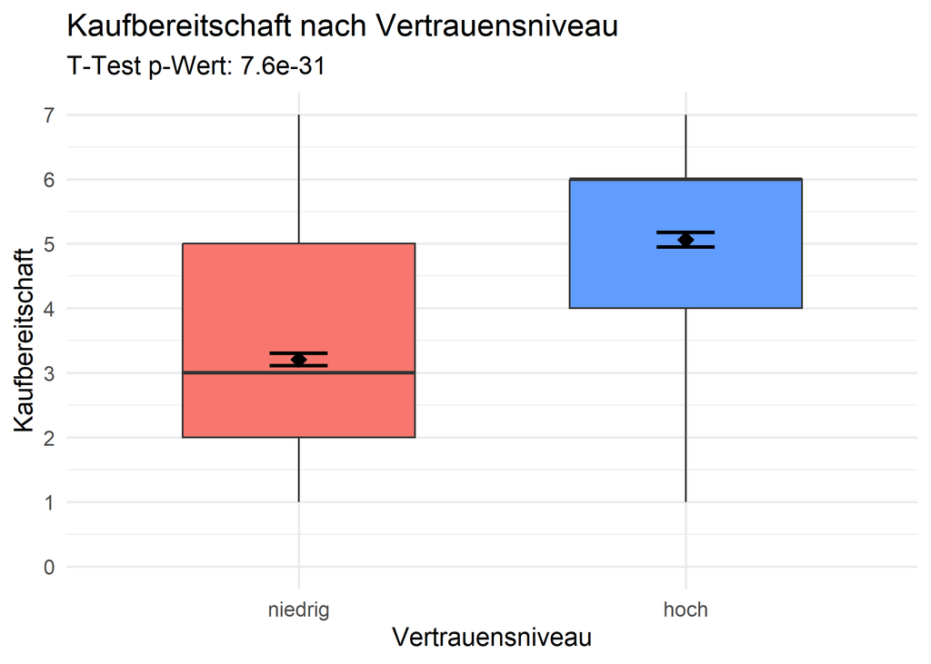

**Beschreibung:**

Die dargestellte Grafik zeigt die Kaufbereitschaft von Personen mit unterschiedlich ausgeprägtem Vertrauen gegenüber einem Unternehmen oder Produkt, gemessen auf einer siebenstufigen Skala. Die x-Achse unterteilt die Teilnehmenden in zwei Gruppen: solche mit niedrigem Vertrauen und solche mit hohem Vertrauen. Diese Einteilung basiert auf dem Medianwert der Vertrauensvariable. Die y-Achse gibt die Kaufbereitschaft an, also wie stark Teilnehmende zum Kauf bereit wären. Zur Visualisierung wurden Boxplots verwendet, die die Verteilung der Kaufbereitschaft innerhalb der jeweiligen Gruppe zeigen.

Jede Box repräsentiert dabei den Bereich zwischen dem 25%- und dem 75%-Perzentil. Bei Personen mit niedrigem Vertrauen liegt das untere Quartil bei einem Wert von etwa 2 – das bedeutet, dass 25% der Teilnehmenden in dieser Gruppe eine Kaufbereitschaft von höchstens 2 angeben. Das obere Quartil liegt bei 5, was heißt, dass 75% der Teilnehmenden eine Kaufbereitschaft von 5 oder weniger aufweisen. Der Median, also der Wert, der die Gruppe in zwei gleich große Hälften teilt, liegt bei ungefähr 3. In der Gruppe mit hohem Vertrauen verschiebt sich dieses Bild deutlich: Das untere Quartil liegt bei etwa 4, das obere bei 6, und der Median liegt bei einem Wert von rund 6. Neben dem Median ist in der Grafik auch der Mittelwert als schwarzer Punkt dargestellt – dieser liegt bei rund 3,2 für die Gruppe mit niedrigem Vertrauen und bei etwa 5,1 für die Gruppe mit hohem Vertrauen. Die schwarzen Fehlerbalken geben den Standardfehler des Mittelwerts an.

Unterhalb des Titels ist der p-Wert des zugehörigen t-Tests angegeben, der die statistische Signifikanz der Mittelwertsdifferenz zwischen den beiden Gruppen misst. Dieser Wert nahezu null, was auf einen hochsignifikanten Unterschied zwischen beiden Gruppen hinweist.

**Interpretation:**

Die Grafik zeigt deutlich, dass Vertrauen eine zentrale Rolle bei Kaufentscheidungen spielt. Personen mit hohem Vertrauen weisen eine deutlich höhere Kaufbereitschaft auf als jene mit niedrigem Vertrauen. Die durchschnittliche Kaufbereitschaft liegt in der Gruppe mit hohem Vertrauen bei etwa 5,1 Punkten, während sie bei niedrigem Vertrauen nur rund 3,2 beträgt – eine Differenz von nahezu zwei Skalenpunkten auf einer siebenstufigen Skala. Auch der Median unterscheidet sich sichtbar: Er liegt bei der Gruppe mit hohem Vertrauen bei etwa 6, während er in der Gruppe mit niedrigem Vertrauen nur etwa 3 beträgt. Diese Differenz ist statistisch hochsignifikant, was durch den sehr kleinen p-Wert des T-Tests belegt wird.

Die Ergebnisse deuten darauf hin, dass Vertrauen nicht lediglich eine begleitende psychologische Variable ist, sondern inhaltlich bedeutsam das Konsumverhalten beeinflusst. Interessant ist dabei auch, dass sich dieser Effekt unabhängig vom Treatment zeigt. Das legt nahe, dass Vertrauen als psychologischer Vermittlungsmechanismus – also als Mediator – zwischen Kostentransparenz und der Kaufbereitschaft wirken könnte. Die Wirkung der Transparenzmaßnahme auf die Kaufentscheidung könnte somit maßgeblich über ein gestärktes Vertrauen vermittelt sein. Die vorliegenden Ergebnisse liefern eine wichtige empirische Grundlage für diese Annahme und machen eine weiterführende Mediationanalyse sinnvoll.

# Regressionsanalyse

Sie haben nun ihren Datensatz kennengelernt und es scheint so, als ob insbesondere Personen, welche transparente Kosten sehen, dazu neigen, das Produkt zu kaufen. Doch um ihre deskriptiven Analysen zu erhärten, wollen Sie im folgenden eine Analyse mittels Regressionen durchführen.

11. Betrachten Sie hier noch einmal das erste Experiment (`daten_exp1`). Führen Sie eine Regression durch, bei der Ihnen `everlane` als abhängige Variable dient. Als erklärende Variable nutzen Sie das `treatment`. Erstellen sie eine weitere Regression, die zusätzlich noch für die folgenden Variablen kontrolliert:
- Alter
- Bildungsstufe
- Einkommen
- Geschlecht

Stellen Sie die Regressionsergebnisse in einer Tabelle mit stargazer oder modelsummary dar!

Beschreiben und interpretieren Sie ihre Ergebnisse. Gehen Sie insbesondere auf folgende Fragen ein:

- Lässt sich der Effekt des Treatments auf die Entscheidung der Kunden kausal interpretieren?
- Ist es wichtig auf weitere Faktoren zu kontrollieren?
- Beziehen Sie sich hier auch auf die Ergebnisse aus Aufgabe 5.

|  | Everlane-Gutschein | Everlane-Gutschein |
| --- | --- | --- |
| Intercept | 0.556*** | 0.686*** |
|  | (<0.001) | (<0.001) |
| Kostentransparenz | 0.152*** | 0.155*** |
|  | (<0.001) | (<0.001) |
| Alter |  | -0.002 |
|  |  | (0.210) |
| Einkommen |  | -0.012 |
|  |  | (0.192) |
| Bildung |  | -0.001 |
|  |  | (0.976) |
| Weiblich |  | 0.091* |
|  |  | (0.032) |
| Num.Obs. | 505 | 505 |
| R2 | 0.025 | 0.039 |
| R2 Adj. | 0.023 | 0.030 |
| F | 12.797 | 4.072 |

+ p < 0.1, * p < 0.05, ** p < 0.01, *** p < 0.001

**Interpretation:**

Sowie die Ergebnisse der deskriptiven Analyse, zeigen auch die der Regressionsanalyse einen klaren Zusammenhang zwischen Kostentransparenz und der Wahl von Everlane-Produkten. In beiden Modellen hat das Treatment einen starken und hochsignifikaten positiven Effekt (p < 0.001). Der Koeffizient liegt bei etwa 0,152 bis 0,155, was bedeutet, dass Personen in der Treatmentgruppe durch die transparenten Kosten eine deutlich höhere Wahrscheinlichkeit haben, sich für Everlane zu entscheiden. Der Effekt lässt sich kausal interpretieren, da die Zuteilung zum Treatment zufällig erfolgte (Randomisierung). Anhand der Ergebnisse aus Aufgabe 5 lässt sich dies bestätigen, da zu sehen ist, dass sich die Gruppen in wichtigen Merkmalen wie Alter, Einkommen oder Bildung fast nicht unterscheiden. Diese Randomisierung sorgt dafür, dass der beobachtete Effekt tatsächlich auf die Kostentransparenz zurückgeführt werden kann und nicht durch andere Faktoren verzerrt wird. Die Kontrollvariablen haben kaum Einfluss auf den Treatment-Effekt. Weder Alter, Bildung noch das Einkommen zeigen signifikante Zusammenhänge mit der Wahlentscheidung. Einzige Ausnahme ist hier das Geschlecht. Frauen entscheiden sich etwas häufiger für Everlane (p = 0.032). Dennoch ändert sich der Treatment-Effekt durch die Aufnahme dieser Kontrollvariablen kaum, was seine Robustheit unterstreicht. Die ähnliche Modellgüte in beiden Spezifikationen, deutet ebenfalls darauf hin, dass die zusätzlichen Kontrollvariablen das Modell nicht wesentlich verbessern. Dies spiegeln auch die Ergebnisse aus Aufgabe 5 wieder, welche bereits gezeigt haben, dass die Variablen zwischen den Gruppen ausgeglichen waren.

Während die bisherigen Analysen zeigen, dass das Treatment einen Effekt hat, stellt sich nun die Frage, warum das so ist. Nun sollten Sie im weiteren Verlauf durch vertiefende Regressionsanalysen prüfen, ob dies auf das Vertrauen der Kunden zurückzuführen ist. Dazu betrachten Sie noch einmal den Datensatz zu Experiment 2 (`daten_exp2`) und untersuchen, ob das Treatment (Kunden sehen transparente Kostenstruktur) zu einer höheren Kaufabsicht führt, weil sie das Vertrauen der Konsumenten in das Unternehmen stärkt.

12. Schauen Sie sich den Einfluss der Kostentransparenz auf die Kaufabsicht in den folgenden zwei Regressionen genauer an und zeigen Sie ihre Ergebnisse nebeneinander:

**1. Regression:** Abhängige Variable ist die Kaufabsicht; die erklärende Variable ist das Treatment.

**2. Regression:** Wie in der 1. Regression, doch kontrollieren Sie hier zusätzlich auf die Variablen Alter, Einkommensniveau, Bildungsstufe und Geschlecht.

Stellen Sie die Regressionsergebnisse in einer Tabelle mit stargazer oder modelsummary dar!

Beschreiben und interpretieren Sie ihre Ergebnisse allgemein. Gehen Sie weiterhin auch speziell auf folgende Fragen ein:

- Sollten die Kontrollvariablen in ihrer zweiten Regression den Koeffizienten des Treatments ändern? Was würden Sie erwarten und warum? Nutzen Sie hierzu die Ergebnisse aus Aufgabe 8.
  - Vergleichen Sie die Regressionskoeffizienten der Treatment-Variable in der ersten und zweiten Regression. Gibt es hier einen signifikanten Unterschied in der Größe des Effekts?
- Bringt ihnen die Regression Vorteile gegenüber einer reinen Darstellung der Mittelwerte wie in Aufgabe 9?
- Ist der Effekt des Treatments auf die Kaufabsicht ihrer Ansicht nach kausal interpretierbar?
  - Welche Voraussetzungen müssen erfüllt sein, damit man diesen Regressionskoeffizienten als kausalen Effekt interpretieren kann?
  - Überlegen Sie sich, wie sich das Ergebnis verändern würde, wenn zusätzlich Vertrauen (trust) in das Modell aufgenommen wird. Würde sich der Effekt von `treatment` verändern? Warum oder warum nicht?

|  | Kaufabsicht | Kaufabsicht |
| --- | --- | --- |
| Intercept | 3.741*** | 3.702*** |
|  | (<0.001) | (<0.001) |
| Kostentransparenz | 0.532** | 0.501** |
|  | (0.001) | (0.003) |
| Alter |  | -0.013+ |
|  |  | (0.076) |
| Einkommen |  | 0.023 |
|  |  | (0.516) |
| Bildung |  | 0.102 |
|  |  | (0.302) |
| Weiblich |  | -0.001 |
|  |  | (0.994) |
| Num.Obs. | 601 | 601 |
| R2 | 0.017 | 0.025 |
| R2 Adj. | 0.015 | 0.016 |
| F | 10.435 | 3.009 |

**Beschreibung:**

Die Tabelle stellt zwei Regressionsmodelle dar, die den Zusammenhang zwischen Kostentransparenz und Kaufabsicht untersuchen. Im ersten Modell (Spalte 1) wird nur der Einfluss der Kostentransparenz betrachtet. Der positive Koeffizient von 0.532 ist statistisch signifikant (p < 0.01). Dies bedeutet, dass die Kaufabsicht der Treatmentgruppe durchschnittlich um etwa einen halben Punkt auf der 7er-Skala höher liegt als in der Kontrollgruppe. Das zweite Modell (Spalte 2) berücksichtigt zusätzlich die Kontrollvariablen Alter, Einkommen, Bildungsstufe und Geschlecht. Der Effekt der Kostentransparenz bleibt mit 0.501 nahezu gleich groß und ebenfalls signifikant. Von den Kontrollvariablen zeigt keine einen statistisch bedeutsamen Einfluss auf die Kaufabsicht. Die erklärte Varianz ist in beiden Fällen relativ niedrig (R² von 0.017 bzw. 0.025), was hier nicht ungewöhnlich ist, da der Fokus primär auf der kausalen Einschätzung liegt und nicht auf der Erklärung der gesamten Varianz. Die F-Tests bestätigen, dass beide Modelle insgesamt signifikant sind.

**Interpretation:**

Auf Basis der Balancing-Tests aus Aufgabe 8 war zu erwarten, dass die Kontrollvariablen den Treatment-Effekt nur minimal beeinflussen würden. Die dortigen Ergebnisse zeigten, dass die Randomisierung erfolgreich war. Bis auf einen geringfügigen Altersunterschied (Treatmentgruppe ist im Schnitt 2,2 Jahre jünger, p=0.02) unterscheiden sich die Gruppen nicht signifikant in den demografischen Merkmalen. Theoretisch sollte daher der Treatment-Koeffizient bei Hinzunahme der Kontrollvariablen stabil bleiben.

Diese Erwartung wird durch die aktuellen Regressionsergebnisse bestätigt. Der Treatment-Effekt verringert sich lediglich von 0.532 auf 0.501, was eine marginale Veränderung von -0.031 Punkten auf der 7er-Skala bedeutet. Diese minimale Anpassung lässt sich vollständig durch den bekannten Altersunterschied erklären. Die Stabilität des Koeffizienten verdeutlicht, dass die Kostentransparenz unabhängig von demografischen Faktoren wirkt.

Im Vergleich zu den Mittelwertanalysen aus Aufgabe 9 bietet die Regressionsmethode wesentlich tiefere Einblicke in die Zusammenhänge. Während Mittelwertvergleiche nur Unterschiede zwischen Gruppen aufzeigen können, ermöglicht die Regression eine präzisere Schätzung des Treatment-Effekts durch die Berücksichtigung möglicher Störfaktoren. Besonders wichtig ist hier die Fähigkeit, konkrete Effektstärken zu quantifizieren. So zeigt sich, dass die Kostentransparenz die Kaufabsicht um etwa eine halben Punkt auf der Skala erhöht. Diese präzise Quantifizierung geht deutlich über die bloße Feststellung eines signifikanten Unterschieds hinaus.

Die Stärke der Regression ist besonders im Umgang mit dem kleinen Altersunterschied zwischen den Gruppen zu sehen. Anders als bei einfachen Mittelwertvergleichen wie in Aufgabe 9, können hier solche Unterschiede statistisch kontrolliert werden, was zu einer sauberen Schätzung des eigentlichen Treatment-Effekts führt. Zusätzlich bietet die Regression wichtige Kennzahlen zur Modellgüte und ermöglicht die gleichzeitige Berücksichtigung mehrerer Einflussfaktoren, was die Aussagekraft der Ergebnisse deutlich erhöht.

Die potenzielle Rolle des Vetrauens (`treatment`) wirft interessante Fragen auf. Theoretisch wäre zu erwarten, dass ein Teil des Treatment-Effekts über eine Erhöhung des Vertrauens wirkt. Würde man diesen Faktor in die Regression aufnehmen, sollte sich der direkte Effekt der Kostentransparenz entsprechend verringern. Dies würde nicht nur den Wirkmechanismus genauer beschreiben, sondern auch wichtige Hinweise für die praktische Umsetzung von Transparenzmaßnahmen liefern. Der verbleibende direkte Effekt würde dann jenen Anteil darstellen, der über andere psychologische Mechanismen als das Vertrauen wirkt.

Sie haben nun gesehen, dass es auch hier einen direkten Effekt des Treatments (transparente Kostenstrukur) auf die Kaufabsicht gibt. Doch um die dahinter liegenden Mechanismen zu verstehen, müssen Sie tiefer in psychologische Prozesse eintauchen. Experiment 2 zeigt dafür ein entsprechendes Design, um zu testen, ob Vertrauen als vermittelnder Mechanismus eine Rolle spielt. Im nächsten Schritt analysieren Sie nun selbst diese Beziehung mit theoretischen Modellen und Regressionsmethoden, um ein Gefühl dafür zu bekommen, wie sich direkte und indirekte Effekte voneinander unterscheiden.

13. Bevor Sie im nächsten Schritt ein konkretes DAG zu einem psychologischen Mediationsmechanismus erstellen, machen Sie sich zunächst mit den theoretischen Grundlagen von Directed Acyclic Graphs (DAGs) vertraut. DAGs (gerichtete azyklische Graphen) sind ein nützliches Werkzeug in der Kausalanalyse.

Beantworten Sie folgende theoretische Fragen zu DAGs:

- Wofür werden DAGs in der empirischen Forschung verwendet?
- Nennen und beschreiben Sie zwei zentrale Knotentypen in einem DAG: Confounder und Mediator.
- Worin besteht der zentrale Unterschied, ob Vertrauen als Kontrollvariable (Confounder) oder als Mediator behandelt wird - und warum ist Letzteres entscheidend für das Verständnis psychologischer Prozesse im vorliegenden Experiment?

**Wofür werden DAGs in der empirischen Forschung verwendet?**

DAGs dienen dazu, Annahmen über kausale Beziehungen zwischen Variablen visuell und strukturiert darzustellen. Kausalität fließt dabei immer in eine Richtung und wird durch Pfeile verdeutlicht. Mithilfe von DAGs kann man den zugrunde liegenden Datengenerierungsprozess modellieren und Entscheidungen darüber treffen, welche Variablen kontrolliert oder ausgeschlossen werden müssen, um unverzerrte kausale Effektschätzungen zu erhalten.

**Nennen und beschreiben Sie zwei zentrale Knotentypen in einem DAG: Confounder und Mediator.**

Ein Confounder ist eine Variable, welche sowohl die unabhängige Variable als auch die abhängige Variable beeinflusst. Wenn ein Confounder nicht kontrolliert wird, kann er zu einer verzerrten Schätzung des kausalen Effekts führen.

Bei einem Mediator handelt es sich um einen Mittler des Gesamteffekts - er liegt kausal zwischen der unabhängigen und der abhängigen Variable. Man sollte auf einen Mediator nicht kontrollieren, da dies zu einer Überanpassung des Modells führen würde.

**Worin besteht der zentrale Unterschied, ob Vertrauen als Kontrollvariable (Confounder) oder als Mediator behandelt wird - und warum ist Letzteres entscheidend für das Verständnis psychologischer Prozesse im vorliegenden Experiment?**

Wenn Vertrauen als Confounder behandelt wird, würde agenommen werden, dass Vertrauen bereits vor dem Treatment existiert und sowohl die Wahrnehmung der Kostenstruktur als auch die Kaufabsicht beeinflusst. Vertrauen wäre somit eine Störvariable, die kontrolliert werden müsste, um keinen verzerrten Effekt des Treatments zu messen.

Vertrauen als Mediator wird durch das Treatment beeinflusst, also die Offenlegung der Kostenstruktur und beeinflusst anschließend die Kaufabsicht. Es liegt also ein indirekter kausaler Pfad vor: eine Offenlegung der Kostenstruktur fördert das Vertrauen in ein Produkt / eine Marke, was wiederum zu einer höheren Kaufabsicht führt. Diese Annahme ist entscheindend für das Verständnis psychologischer Prozesse im vorliegenden Experiment, da sich psychologische Theorien nicht nur für ob ein Effekt existiert interessiert, sondern wie er zustande kommt. Nur wenn Vertrauen als Mediator betrachtet wird, kann man untersuchen, ob und in welchem Ausmaß die Wirkung der transparenten Kostenstruktur über Vertrauen läuft.

14. Nutzen Sie nun das Directed Acyclic Graph (DAG), um die Beziehungen zwischen den Variablen Treatment (T), Vertrauen (V) und Kaufbereitschaft (K) zu analysieren und den vermuteten Mediationsmechanismus zu untersuchen.

Beschreiben und interpretieren Sie ihr DAG und die Beziehungen zwischen den Variablen. Gehen Sie insbesondere auf folgende Fragen und Aspekte ein:

- Begründen und erklären Sie die Struktur und den Aufbau ihres DAGs.
- Welche Annahmen müssen getroffen werden, damit Vertrauen tatsächlich als Mediator interpretiert werden kann?
- Welche Verzerrungen oder Störfaktoren könnten den Mediator-Effekt von Vertrauen beeinflussen? Wie könnte dies die Ergebnisse verzerren?

*Hinweis 1:* Für die Erstellung des DAGs können Sie das Paket `dagify` verwenden. Als Grundlage und Hilfsmittel können Sie die Vorlesungsfolien nutzen.

*Hinweis 2:* Eine direkte Visualisierung des DAGs in `R` ist schön, aber keine Pflicht. Sie können das DAG auch in Word/PowerPoint zeichnen und ihre Grafik mittels `include_graphics()` einfügen.

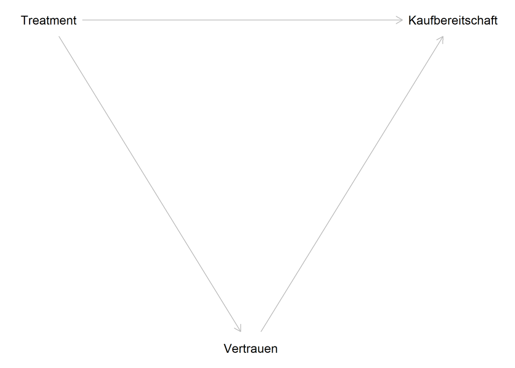

**Beschreibung:**

Das DAG stellt grafisch die Beziehungen zwischen Treatment, Vertrauen und Kaufbereitschaft dar. Das Treatment (die transparente Kostenstruktur) beeinflusst das Vertrauen der Konsumenten in eine Marke oder ein Produkt. Ein höheres Vertrauen führt wiederum zu einer höheren Kaufbereitschaft. Zusätzlich gibt es einen direkten Effekt des Treatments auf die Kaufbereitschaft, also wirkt das Treatment nicht nur indirekt über Vertrauen, sondern auch direkt. Dieses Modell zeigt somit, dass das Treatment sowohl direkte als auch indirekte Effekte auf die Kaufabsicht hat, wobei Vertrauen als vermittelnder Mediator fungiert.

**Interpretation:**

Um Vertrauen als Mediator betrachten zu können, müssen bestimmte Annahmen erfüllt sein. Zunächst muss es plausibel sein, dass das Treatment das Vertrauen beeinflusst und dass Vertrauen wiederum die Kaufbereitschaft beeinflusst. In unserem Fall erscheint das nachvollziehbar, da die Offenlegung der Kostenstruktur das Vertrauen in die Marke stärken kann, was die Kaufbereitschaft erhöht. Außerdem darf Vertrauen nicht auf das Treatment zurückwirken, sodass keine zyklischen Abhängigkeiten entstehen – auch das ist hier gegeben. Wichtig ist außerdem, dass keine unbeobachteten Variablen existieren, die sowohl Vertrauen als auch Kaufbereitschaft beeinflussen und so den Zusammenhang verfälschen könnten. Beispielsweise könnten Eigenschaften wie Optimismus oder generelle Konsumfreude beides beeinflussen. Werden solche Faktoren nicht kontrolliert, könnte der Effekt von Vertrauen überschätzt werden, da beide Variablen von einem dritten Einflussfaktor abhängen. Darüber hinaus können Messfehler insbesondere im Mediator Vertrauen den Mediator-Effekt verzerren, indem sie diesen entweder abschwächen oder fälschlich verstärken. Schließlich sollten keine wichtigen alternative Mediatoren fehlen, die den Effekt des Treatments auf die Kaufbereitschaft erklären könnten, da sonst die Rolle von Vertrauen überschätzt wird.

15. Führen Sie nun eine Regression durch, bei der Ihnen `trust` (Vertrauen) als abhängige Variable dient. Weiterhin soll ihnen `treatment` als erklärende Variable dienen. Erstellen sie eine weitere Regression, die zusätzlich noch für die folgenden Variablen kontrolliert: Alter, Einkommensniveau, Bildungsstufe und ob die Personen weiblich sind.

Stellen Sie die Regressionsergebnisse in einer Tabelle mit stargazer oder modelsummary dar!

Beschreiben und interpretieren Sie ihre Ergebnisse. Gehen Sie bei der Interpretation der Ergebnisse insbesondere auf folgende Fragen ein:

- Macht es ihrer Ansicht nach Sinn auf die zusätzlichen Variablen in Regression 2 zu kontrollieren? Worauf müssen Sie besonders achten?
- Was bedeutet ein signifikanter positiver Koeffizient für treatment in Bezug auf Vertrauen?
- Warum ist dieser Pfad (Treatment ➝ Trust) notwendig, damit eine Mediation überhaupt möglich ist?
- Überlegen Sie, ob andere Faktoren, die Sie möglicherweise nicht berücksichtigt haben, diesen Zusammenhang ebenfalls erklären könnten.

|  | Vertrauen | Vertrauen |
| --- | --- | --- |
| Intercept | 4.821*** | 4.716*** |
|  | (<0.001) | (<0.001) |
| Kostentransparenz | 0.473*** | 0.454*** |
|  | (<0.001) | (<0.001) |
| Alter |  | -0.001 |
|  |  | (0.872) |
| Einkommen |  | -0.021 |
|  |  | (0.391) |
| Bildung |  | 0.058 |
|  |  | (0.388) |
| Weiblich |  | 0.179 |
|  |  | (0.118) |
| Num.Obs. | 601 | 601 |
| R2 | 0.029 | 0.035 |
| R2 Adj. | 0.027 | 0.027 |
| F | 17.791 | 4.291 |

**Beschreibung:**

Diese Regressionstabelle zeigt die Ergebnisse zweier linearer Regressionsmodelle, bei denen Vertrauen die abhängige Variable ist. Die zentrale erklärende Variable ist in beiden Modellen die Kostentransparenz. Modell 1 enthält nur das Treatment, in Modell 2 wird zusätzlich für Alter, Einkommen, Bildung und Geschlecht kontrolliert. Im einfachen Modell lässt sich feststellen, dass Kostentransparenz einen signifikanten positiven Effekt auf Vertrauen hat. Der Koeffizient beträgt hier 0,473 und ist auf dem 1%-Niveau signifikant. Das bedeutet, dass Personen, denen die Preisstruktur offengelegt wurde, im Durchschnitt ein höheres Vertrauen in die Marke bzw. das Produkt haben. Bei Betrachtung des erweiterten Modells bleibt der Effekt von Kostentransparenz auf Vertrauen mit einem Koeffizient von 0,454 positiv und signifikant. Die Kontrollvariablen zeigen keinen signifikanten Einfluss auf Vertrauen. Sowohl das Alter, das Einkommen als auch das Bildungsniveau haben sehr geringe und nicht signifikante Effekte. Das Geschlecht hat zwar einen leichten positiven Effekt mit einem Koeffizient von 0.179, dieser ist aber statistisch nicht signifikant.

**Interpretation:**

Es ist sinnvoll, dass zusätzlich in einem weiteren Modell für Alter, Einkommen, Bildung und Geschlecht kontrolliert wurde, da diese Merkmale das individuelle Vertrauen beeinflussen könntren. Man muss besonders darauf achten, dass man nur die Variablen kontrolliert, die keine Mediatoren oder Effekte des Treatments selbst sind, denn sonst würde man Teile des für uns interessanten Effekts herausrechnen. In unserem Fall hier sind die Kontrollvariablen plausibel als Confounder, nicht als Mediatoren, daher gibt es hier keine Probleme.

Der signifikante positive Koeffizient für Kostentransparenz bedeutet, dass eine Offenlegung von Kostenstrukturen einen statistisch gesicherten Vertrauenszuwachs bei Konsumenten auslöst. Dies ist für Unternehmen eine wichtige Erkenntnis, da Vertrauen ein zentraler psychologischer Treiber für Kaufentscheidungen ist.

Der Pfad Treatment -> Vertrauen ist notwendig, da Vertrauen nur als Mediator zwischen Treatment und Kaufabsicht wirken kann, wenn das Treatment auch tatsächlich das Vertrauen beeinflusst. Wenn es keinen Zusammenhang zwischen Treatment und Vertrauen geben würde, wäre auch kein indirekter Effekt über Vertrauen möglich.

In unserer Regressionsanalyse wurde festgestellt, dass alle Kontrollvariablen keinen signifikanten Einfluss auf das Vertrauen haben. Andere Variablen, die sowohl das Vertrauen als auch die Reaktion auf das Treatment beeinflussen könnten, wären beispielsweise Vorerfahrungen mit Unternehmen. Teilnehmende, die bereits gute Erfahrungen mit fairen oder transparenten Unternehmen gemacht haben, könnten eventuell schneller Vertrauen aufbauen. Diese Erfahrungen wurden aber in unserer Analyse nicht berücksichtigt. Außerdem könnten die allgemeine Einstellung und die Werte der Teilnehmenden eine Rolle spielen. Einige Menschen legen mehr Wert auf Transparenz oder Nachhaltigkeit beim Konsum. Für diese Gruppe hat eine transparente Preisstruktur eine größere Bedeutung und sie vertrauen schneller.

16. Nachdem Sie nun den Effekt des Treatments auf das Vertrauen geschätzt und ausgewertet haben, sollen Sie nun testen, ob das Vertrauen als Mediator zwischen Treatment und Kaufabsicht wirkt.

Führen Sie eine Regression durch, bei der Ihnen die Kaufbereitschaft als abhängige Variable dient. Weiterhin sollen die erklärende Variablen nun `treatment`, sowie das Vertrauen (`trust`) umfassen. Erstellen sie eine weitere Regression, die zusätzlich noch auf Alter, Einkommensniveau, Bildungsstufe und ob die Personen weiblich sind, kontrolliert.

Stellen Sie die Regressionsergebnisse passend in einer Tabelle dar!

Beschreiben und interpretieren Sie ihre Ergebnisse. Gehen Sie bei der Interpretation der Ergebnisse insbesondere auf folgende Fragen ein:

- Was könnten Ihrer Ansicht nach Gründe sein, dass `treatment` jetzt nicht mehr signifkant ist? Woran könnt das im Detail liegen?
- Warum ist es wichtig, `trust` und `treatment` gemeinsam in einem Modell zu betrachten?
- Warum könnte `trust` eine “notwendige Bedingung” sein, damit Transparenz der Kostenstruktur zu höherer Kaufbereitschaft führt?

|  | Kaufabsicht | Kaufabsicht |
| --- | --- | --- |
| Intercept | -0.178 | -0.155 |
|  | (0.495) | (0.735) |
| Kostentransparenz | 0.148 | 0.129 |
|  | (0.289) | (0.356) |
| Vertrauen | 0.813*** | 0.818*** |
|  | (<0.001) | (<0.001) |
| Alter |  | -0.013* |
|  |  | (0.043) |
| Einkommen |  | 0.041 |
|  |  | (0.176) |
| Bildung |  | 0.055 |
|  |  | (0.507) |
| Weiblich |  | -0.148 |
|  |  | (0.292) |
| Num.Obs. | 601 | 601 |
| R2 | 0.317 | 0.327 |
| R2 Adj. | 0.315 | 0.320 |
| F | 139.008 | 48.027 |

**Beobachtung:**

**Interpretation:**

Überraschend ist, dass das Treatment jetzt, wo Vertrauen mit im Modell enthalten ist, nicht mehr signifikant ist. Das deutet darauf hin, dass ein großer Teil des Effekts von Treatment über Vertrauen vermittelt wird. Sobald man Vertrauen berücksichtigt, ist der direkte Effekt sehr gering, was ein typisches Anzeichen für Mediation ist. Es ist wichtig, sowohl Vertrauen als auch Kostentransparenz gemeinsam im Modell zu betrachten, da nur so unterschieden werden kann, ob Treatment direkt auf die Kaufabsicht wirkt oder ob der Effekt indirekt über Vertrauen läuft. Wenn man Vertrauen nicht berücksichtigen würde, würde man den Gesamteffekt schätzen. Mit Vertrauen im Modell kann man den direkten Effekt isolieren und so besser verstehen, welche Rolle Vertrauen wirklich spielt.

Vertrauen könnte eine “notwendige Bedingung” sein, damit Transparenz der Kostenstruktur zu höherer Kaufbereitschaft führt, da Vertrauen hier als zentrale vermittelnde Größe wirkt. Nur wenn die Kostentransparenz tatsächlich zu einem höheren Vertrauen führt, kann dieses Vertrauen wiederum die Kaufabsicht der Konsumenten steigern. Wenn Vertrauen nicht erhöht wird, bleibt der gewünschte Effekt der Transparenz auf das Verhalten aus bzw. ist deutlich geringer. Daher ist Vertrauen eine notwendige Bedingung, damit der Mechanismus Transparenz erhöht Kaufabsicht überhaupt funktioniert.

In den vorangegangenen Modellen wurde untersucht, ob das Treatment (Kostentransparenz) das Vertrauen in das Unternehmen beeinflusst und ob Vertrauen wiederum mit der Kaufabsicht zusammenhängt.

17. Bewerten Sie das experimentelle Design der Studie 2. Gehen Sie dabei auch darauf ein, inwiefern Ihre Ergebnisse aus Aufgabe 13 bis 16 das theoretische Verständnis von Vertrauensbildung in der Konsumentenpsychologie bestätigt oder infrage stellt. Welche Stärken und Schwächen sehen Sie bezüglich der internen Validität und der Kausalitätsaussagen? Diskutieren Sie zudem kurz, inwiefern die Ergebnisse auf andere Bevölkerungsgruppen oder kulturelle Kontexte übertragbar sind.

*Hinweis:* Informationen zum Verständnis der Vertrauensbildung in der Konsumentenpsychologie können Sie [in dem folgenden Artikel](https://www.shs-conferences.org/articles/shsconf/pdf/2021/26/shsconf_appsconf2021_03019.pdf) auf Seite 2 bis 5 nachlesen.

**Beschreibung und Beurteilung des Designs:**

Studie 2 nutzt ein experimentelles Design mit einer klaren Treatment- und Kontrollgruppe, um den kausalen Effekt von Kostentransparenz auf Vertrauen und Kaufabsicht zu untersuchen. Durch die Randomisierung der Teilnehmer in die Gruppen wird eine hohe interne Validität gewährleistet. Der Einsatz eines Mediationsmodells (Treatment → Vertrauen → Kaufabsicht) ist dabei besonders geeignet, um psychologische Mechanismen wie Vertrauensbildung zu analysieren. Die schrittweise Prüfung (DAG, Regressionsreihenfolge, Mediation) ermöglicht es, nicht nur den Effekt nachzuweisen, sondern auch besser zu verstehen, wie er zustande kommt.

**Bestätigung durch Aufgaben 13–16:**

Die Ergebnisse der Aufgaben 13–16 stützen das theoretische Modell aus der Konsumentenpsychologie: Vertrauen fungiert nicht nur als Reaktion auf transparente Kommunikation, sondern auch als psychologische Vermittlungsinstanz für das tatsächliche Verhalten. Das Treatment erhöht das Vertrauen signifikant, und Vertrauen wiederum ist ein starker Prädiktor für Kaufabsicht. Sobald Vertrauen in das Modell aufgenommen wird, verschwindet der direkte Effekt des Treatments – ein starker Hinweis auf eine vollständige Mediation.

Dieser Befund bestätigt zentrale Thesen aus der Literatur (z.B. Zsigmondová et al., 2021): Vertrauen ist eine Voraussetzung für erfolgreiche langfristige Kundenbeziehungen, reduziert Unsicherheit und Transaktionskosten und bildet eine Grundlage für Loyalität, insbesondere in Situationen mit asymmetrischer Information – wie z.B. bei Online-Produkten oder innovativen Geschäftsmodellen.

**Stärken des Designs:**

Das Studiendesign weist mehrere Stärken auf, die zur Robustheit der Ergebnisse beitragen. So sorgt die Randomisierung der Gruppen dafür, dass potenzielle Störfaktoren gleichmäßig verteilt sind. Dadurch werden systematische Verzerrungen durch Drittvariablen minimiert und die interne Validität der Untersuchung gestärkt. Darüber hinaus ermöglicht die mehrstufige Regressionsanalyse eine differenzierte Betrachtung sowohl direkter als auch indirekter Effekte, beispielsweise durch Mediation. Die gezielte Operationalisierung zentraler psychologischer Konstrukte wie Vertrauen oder Kaufabsicht erlaubt zudem eine theoriegeleitete Prüfung von Hypothesen und trägt zur inhaltlichen Validität der Studie bei.

**Schwächen und Limitationen:**

Gleichzeitig gibt es einige Limitationen, die bei der Interpretation der Ergebnisse berücksichtigt werden sollten. So könnten unbeobachtete Confounder wie Persönlichkeitsmerkmale (etwa generelle Skepsis oder Tendenzen zu sozial erwünschtem Verhalten) sowohl das Vertrauen als auch die Kaufabsicht beeinflussen, ohne erfasst worden zu sein. Auch Messfehler beim Mediator “Vertrauen” können dazu führen, dass der Mediationseffekt unter- oder überschätzt wird. Ein weiterer kritischer Punkt betrifft die Selbstangabe der Kaufabsicht, die nicht notwendigerweise mit tatsächlichem Verhalten übereinstimmt. Das schränkt die externe Validität der Ergebnisse ein, insbesondere im Hinblick auf reale Kaufentscheidungen. Schließlich schützt zwar die Randomisierung vor internen Verzerrungen, sie kontrolliert jedoch nicht automatisch für soziale oder kulturelle Kontexteffekte, die das Verhalten in der realen Welt ebenfalls beeinflussen könnten.

**Übertragbarkeit (externe Validität):**

Die Generalisierbarkeit auf andere Bevölkerungsgruppen ist begrenzt, wenn z.B. alle Teilnehmenden aus einem bestimmten Kulturkreis oder Bildungshintergrund stammen. Kulturelle Normen spielen eine wesentliche Rolle bei der Bewertung von Transparenz und Vertrauen – wie der Artikel betont, ist Vertrauen auch kulturell vermittelt (z.B. durch kollektive Normen, Erfahrungen mit Institutionen). In kollektivistisch geprägten Gesellschaften könnte Vertrauen anders entstehen als in individualistisch geprägten, was eine kulturelle Replikation erforderlich macht. Auch das Medium (Online vs. Face-to-Face) kann Einfluss auf die Wirkung von Transparenz und Vertrauen haben.

# Zusatzaufgabe

Zu Beginn des Projektes hatten wir erwähnt, dass die Experimente, welche im Projekt durchgeführt wurden, auf Grund eines Missgeschicks in der Online-Darstellung von unterschiedlichen Produkten zustande kam. Hier wurden von einem privat geführten Online-Händler Geldbörsen in fünf Farbvarianten angeboten, wobei beabsichtigt war, allen Farben eine einheitliche Kostentransparenz-Infografik zuzuordnen. Aufgrund eines Versehens wurde die Infografik jedoch nur bei drei Farben implementiert. Dieses zufällige Ereignis führte zu einer klaren Trennung zwischen den Produkten mit dieser und ohne diese Infografik. Das dadurch entstandene natürliche Experiment sollen Sie sich in der Zusatzaufgabe näher anschauen.

18. Lesen Sie sich den nachfolgenden Text zum Aufbau des natürlichen Experiments innerhalb dieses Papers durch und beantworten anschließend nachfolgende Fragen:

On December 2, 2013, a privately held online retailer launched a holiday gift shop with a single email to its mailing list, promoting a leather wallet offered in five colors (burgundy, black, grey, bone, and tan) and priced at $115.00. Later, at the end of January, to boost post-holiday sales, the retailer decided to add a cost transparency infographic to the online product detail pages for each of the wallet’s five color combinations. The retailer’s intention was to use the same infographic for all wallets since they differed only in color.

However, due to an inadvertent mistake, the infographic was not introduced for two of the wallet colors (bone and tan). Consequently, the cost transparency information was implemented for only three of the five wallet colors (burgundy, black, and grey) over a period of five weeks. This error created a natural experiment, enabling us to test the impact of cost transparency on wallet sales.

Therefore we have the following procedure:

- Operationalization of Cost Transparency: The infographic presented the total cost to produce the wallet, breaking it down into its specific components, namely: leather (14.68 US-Dollar), construction (38.56 US-Dollar), duties (4.26 US-Dollar), and transportation (1.00 US-Dollar). In addition, it included benchmark information indicating that the wallet had a 1.9x markup, in contrast to a 6x markup charged by a competitor. Because wallet colors serve as the basis for treatment assignment, the natural experiment compares “cost transparent” wallets (burgundy, black, and grey) to “non-transparent” wallets (bone and tan).
- Identification Strategy: We use a difference-in-differences approach to compare the daily sales between the treatment (cost transparency) and control (no cost transparency) groups before versus after the introduction of the infographic. By doing so, the design isolates the causal effect of cost transparency on the daily count of wallets sold for each color.
- Control Variables: Given that the cost transparency treatment was implemented by wallet color, and with only five available colors, it was necessary to control for potential confounders. For instance, we include a proxy for time-varying color popularity - the number of page views each wallet color received - and a proxy for time-varying inventory levels.

Beantworten Sie nun die folgenden Fragen in Bezug auf den vorherigen Text:

- Wie ist das natürliche Experiment aufgebaut, und warum wird es als solches klassifiziert?
- Welche Rolle spielt das zufällige Versäumnis, die Infografik bei zwei der fünf Farbvarianten einzuführen, in der Experimentstruktur?
- Warum ist es notwendig, Variablen wie Seitenaufrufe und Lagerbestandsproxies in die Analyse einzubeziehen?
  - Welche potenziellen Verzerrungen könnten auftreten, wenn diese Kontrollvariablen nicht berücksichtigt werden?

**Wie ist das natürliche Experiment aufgebaut, und warum wird es als solches klassifiziert?**

Das natürliche Experiment basiert auf einem unbeabsichtigten Fehler eines Online-Händlers: Bei der Ergänzung einer Infografik zur Kostentransparenz auf Produktseiten von Lederportemonnaies wurde diese nur bei drei von fünf Farbvarianten (burgundy, black, grey) eingebunden – zwei Varianten (bone, tan) blieben ohne die Infografik. Da die Farbvarianten ansonsten identisch waren hinsichtlich Preis, Produktqualität und Beschreibung, ist der einzige systematische Unterschied zwischen den Gruppen die Sichtbarkeit der Kostenstruktur. Die zufällige Zuweisung der Infografik auf Produktebene – nicht beeinflusst durch Kundenauswahl oder Händlerabsicht – entspricht dem Charakter eines natürlichen Experiments, weil sie eine quasi-randomisierte Trennung von Treatment- und Kontrollgruppe ermöglicht, ohne aktives Eingreifen der Forschenden.

**Welche Rolle spielt das zufällige Versäumnis, die Infografik bei zwei der fünf Farbvarianten einzuführen, in der Experimentstruktur?**

Dieses zufällige Versäumnis stellt die Grundlage des natürlichen Experiments dar. Es erzeugt eine exogene Variation in der Informationsdarstellung zwischen ansonsten identischen Produkten. Ohne dieses Versehen gäbe es keine unbeeinflusste Vergleichsgruppe – alle Produkte wären mit der Infografik versehen gewesen. Die „fehlerhafte“ Umsetzung schafft also eine Kontrollgruppe, die zur isolierten Messung des Effekts von Kostentransparenz auf den Absatz genutzt werden kann.

**Warum ist es notwendig, Variablen wie Seitenaufrufe und Lagerbestandsproxies in die Analyse einzubeziehen?**

Seitenaufrufe und Lagerbestände sind wichtige Kontrollvariablen, da sie potenzielle Confounder darstellen: Seitenaufrufe dienen als Proxy für die Popularität der einzelnen Farbvarianten an einem bestimmten Tag. Ohne Kontrolle könnten Unterschiede im Verkauf nicht auf die Infografik, sondern auf eine generell höhere Nachfrage nach bestimmten Farben zurückzuführen sein. Lagerbestandsproxies kontrollieren dafür, ob alle Farben an jedem Tag überhaupt verfügbar waren. Wenn z.B. eine transparente Farbvariante kurzzeitig ausverkauft war, könnten niedrigere Verkaufszahlen fälschlich dem Treatment zugeschrieben werden.

**Welche potenziellen Verzerrungen könnten auftreten, wenn diese Kontrollvariablen nicht berücksichtigt werden?**

Ein mögliches Problem bei der Interpretation der Ergebnisse besteht in sogenannten Scheinkorrelationen: Es könnte beispielsweise sein, dass eine besonders beliebte Produktfarbe zufällig ausschließlich der Treatment-Gruppe zugewiesen wurde. In diesem Fall würde ein Anstieg der Verkaufszahlen fälschlicherweise der Kostentransparenzmaßnahme zugeschrieben, obwohl der tatsächliche Grund die höhere Attraktivität des Produkts ist.

Ein weiterer potenzieller Verzerrungsfaktor ist der Verfügbarkeitsbias. Wenn bestimmte Produkte zeitweise nicht auf Lager waren, könnte dies den Absatz künstlich dämpfen – nicht aufgrund mangelnder Transparenz, sondern schlicht, weil das Produkt nicht verfügbar war. Fehlt diese Information im Datensatz, kann dies zu einer fehlerhaften Interpretation der Maßnahmeneffekte führen.

Zudem besteht das Risiko der Verwechslung von Effekten, wenn keine Kontrolle für externe Einflüsse vorgenommen wird. Ohne geeignete Kontrollvariablen (wie z. B. Wochentage oder saisonale Effekte) besteht die Gefahr, dass der Effekt der Treatment-Maßnahme mit allgemeinen Nachfrageschwankungen oder kurzfristigen Markttrends vermischt wird. Dadurch würde die Schätzung des Effekts verzerrt und unter Umständen fälschlich ein Einfluss der Kostentransparenz unterstellt.

19. Lesen Sie weiterhin das Kapitel [“Difference-in-Differences” in Huntington-Klein (2021)](https://theeffectbook.net/ch-DifferenceinDifference.html), speziell Kapitel 18.1 und 18.2 und beantworten Sie die folgenden Fragen dazu:

Kann eine Difference-in-Differences-Regression helfen, den kausalen Effekt der Kostentransparenz auf die Verkaufszahlen zu identifizieren?

Gehen Sie bei der Beantwortung dieser Frage insbesondere auf die nachfolgenden Punkte ein:

- Welche Art von Variation nutzt eine DiD-Regression in diesem Fall zur Identifikation des Effekts?
- Welche Voraussetzung(en) müssen erfüllt sein, damit DiD eine gültige Kausalschätzung liefert?
  - Was bedeutet die „Parallel Trends“-Annahme in diesem Kontext?
  - Warum reicht es nicht aus, nur zu vergleichen, wie sich die Verkaufszahlen nach der Einführung verändert haben?
- Basierend auf dem Kontext des Buchkapitels zu Difference-in-Differences (DiD) und den Informationen aus `Aufgabe 18`, formulieren Sie bitte die **Regressionsgleichung**, mit der der Effekt der Kostentransparenzmaßnahme mithilfe eines DiD-Ansatzes untersucht werden kann.
  - Definieren Sie dabei klar alle verwendeten Variablen.
  - Stellen Sie die Regressionsgleichung in mathematischer Form dar.
  - Beschreiben und erklären Sie das von Ihnen aufgestellte Modell.

**Kann eine Difference-in-Differences-Regression helfen, den kausalen Effekt der Kostentransparenz auf die Verkaufszahlen zu identifizieren?**

Ja, eine Difference-in-Differences-Regression kann unter bestimmten Voraussetzungen dazu beitragen, den kausalen Effekt der Kostentransparenz auf die Verkaufszahlen zu identifizieren. DiD-Regressionen sind eine gute Methode, um kausale Effekte aus Beobachtungsdaten zu schätzen, wenn eine Intervention wie hier die Einführung der Kostentransparenz zu einem bestimmten Zeitpunkt in einer bestimmten Gruppe eingeführt wird und eine geeignete Vergleichsgruppe vorhanden ist.

Eine DiD-Regression nutzt zeitliche Variation vor vs. nach der Maßnahme (Offenlegung der Kostentransparenz) zwischen Gruppen, die unterschiedlich von der Maßnahme betroffen sind. Die Treatment-Gruppe erhielt die Kostentransparenz-Maßnahme, die Kontrollgruppe hingegen nicht. Die zentrale Idee dahinter ist zu vergleichen, wie stark sich die Verkaufszahlen in der Treatment-Gruppe vor und nach der Einführung verändert haben. Davon kann man dann den Veränderungstrend der Kontrollgruppe im selben Zeitraum abziehen. Diese doppelte Differenz eliminiert systematsiche zeitliche Effekte, die beide Gruppen betreffen und liefert so den isolierten Effekt der Maßnahme.

Damit DiD eine gültige Kausalschätzung liefert, ist eine wichtige Voraussetzung die Annahme paralleler Trends. Diese Annahme sagt aus, dass sich in Abwesenheit der Maßnahme die Verkaufszalen in der Treatment- und der Kontrollgruppe über die Zeit gleich entwickelt hätten. Dies bedeutet also, dass die Differenz zwischen den Gruppen vor der Intervention auch ohne Maßnahme konstant bleibt. Nur wenn diese Annahme gilt, lässt sich der Unterschied nach der Intervention auch wirklich durch die Maßnahme Offenlegung der Kostentransparenz erklären.

Es reicht nicht aus, nur zu vergleichen, wie sich die Verkaufszahlen nach der Einführung verändert haben, da sich Verkaufszahlen auch aus anderen Gründen über die Zeit verändern können. Dies könnte bspw. saisonbedingt sein, aufgrund der wirtschaftlichen Lage, werbungsbedingt oder ähnlichem. Ein einfacher Vorher-Nachher-Vergleich würde diese Effekte fälschlicherweise dem Treatment zuschreiben. Die Kontrollgruppe dient dazu, solche zeitlichen Veränderungen herauszurechnen.

Eine passende Regressionsgleichung, mit der der Effekt der Kostentransparenzmaßnahme mithilfe eines DiD-Ansatzes untersucht werden kann, ist die Folgende:

$Y_{it} = \beta_0 + \beta_1 \cdot \text{Treat}_i + \beta_2 \cdot \text{Post}_t + \beta_3 \cdot (\text{Treat}_i \times \text{Post}_t) + \epsilon_{it}$

Dabei steht Y für die Verkaufszahlen für Einheit i zum Zeitpunkt t, Treat ist 1, wenn Einheit i zur Treatment-Gruppe gehört - sonst ist diese 0, Post ist 1, wenn Zeitpunkt t nach der Einführung der Maßnahme liegt - sonst ist diese 0, Treat x Post ist der Interaktionsterm bzw. der DiD-Treatment-Indikator und episoln ist der Fehlerterm. Beta0 beschreibt den durchschnittlichen Verkaufswert in der Kontrollgruppe vor der Maßnahme, Beta1 der Unterschied zwischen Treatment- und Kontrollgruppe vor der Maßnahme, Beta2 die Veränderung der Verkaufszahlen nach der Maßnahme in der Kontrollgruppe und Beta3 für den kausalen Effekt der Maßnahme - die Differenz der Differenzen. Nur Beta3 ist für uns der interessante Schätzer für den Effekt der Kostentransparenz. Er gibt an, wie stark sich die Verkaufszahlen in der Treatment-Gruppe über die Zeit im Vergleich zur Kontrollgruppe verändert haben - also den Difference-in-Differences-Effekt.

20. Zum Abschluss des Projekts sollen Sie sich das oben beschriebene natürliche Experiment genauer anschauen. Lesen Sie hierzu die Daten (`Experiment3.csv`) in R ein. Nennen Sie den Datensatz `daten_exp3`. Erstellen Sie eine Variable `log_units`, die die logarithmierte Anzahl an verkauften Einheiten darstellt.

Erstellen Sie weiterhin eine passende Grafik, die die durchschnittliche Anzahl der verkauften Produkte je Treatment pro Woche abbildet. Fügen Sie weiterhin eine vertikale Linie für den 28. Januar 2014 in ihre Grafik ein, welche die Einführung der Kostentransparenz markiert.

Beschreiben und interpretieren Sie ihre Grafik. Gehen Sie insbesondere auf die Entwicklung der durchschnittlichen Verkaufszahlen in beiden Gruppen vor und nach dem 28. Januar ein. Gibt es visuelle Hinweise auf eine Wirkung der Kostentransparenz?

- Angenommen, beide Gruppen (Treatment und Kontrolle) zeigen vor der Einführung der Kostentransparenz einen gleich starken Anstieg der durchschnittlich verkauften Einheiten. Was würde das für die Interpretation der Maßnahme im Rahmen eines Difference-in-Differences-Ansatzes bedeuten?

*Hinweis:* Für die Ableitung der Wochen aus dem Datumsformat kann die Funktion `isoweek()` aus dem Paket `lubridate` verwendet werden.

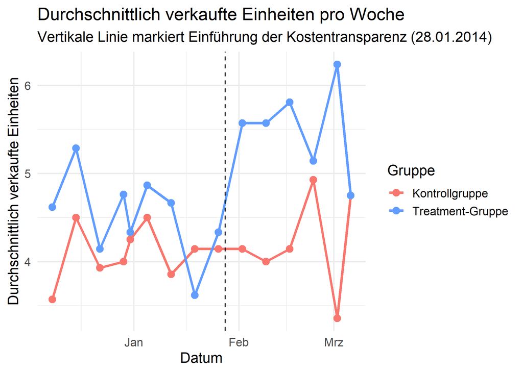

**Beschreibung:**

**Interpretation:**

Ein erster Blick auf den Verlauf der Linien zeigt, dass die Verkaufszahlen der Treatment-Gruppe nach der Einführung der Maßnahme deutlich stärker steigen als die der Kontrollgruppe. Während beide Gruppen zuvor einen vergleichbaren Verlauf mit Auf und Abs zeigen, setzt nach dem Stichtag in der Treatment-Gruppe ein sprunghafter Anstieg ein, der über den zuvor beobachteten Trend hinausgeht. Dies ist ein Anzeichen dafür, dass die Transparenzmaßnahme eine Wirkung hatte.

Wenn beide Gruppen vor dem Stichtag einen vergleichbaren Trend aufweisen (Parallel-Trends-Annahme von Aufgabe 19 erfüllt), lässt sich der Effekt der Maßnahme durch den Unterschied in der Veränderung zwischen beiden Gruppen nach dem Stichtag identifizieren. Der DiD-Ansatz misst also nicht den absoluten Unterschied zwischen den Gruppen, sondern wie stark sich die Veränderung unterscheidet.

Es gibt also visuelle Hinweise auf eine Wirkung der Kostentransparenz. Da beide Gruppen vor der Maßnahme ähnliche Trends hatten, stärkt dies die Annahme, dass die beobachteten Effekte kausal auf die Transparenzmaßnahme zurückzuführen sind. Dass sich die Verkaufszahlen am Ende in beiden Gruppen wieder annähern, könnte eventuell auf kurzfristige Einflüsse wie bspw. saisonale Schwankungen zurückzuführen sein, die unabhängig von der Transparenzmaßnahme wirken. Insgesamt liefert der Verlauf aber überzeugende visuelle Hinweise auf eine Wirkung der Kostentransparenz.

21. Erstellen Sie eine (mehrere) weitere passende Grafik(en), die die durchschnittlich verkauften Einheiten pro Tag in Treatment und Kontrolle vor und nach der Einführung der Kostentransparenz abbildet. Ergänzen Sie in ihrer Grafik die jeweiligen Standardfehler als Fehlerbalken. Beschreiben und interpretieren Sie ihre Grafik. Gehen Sie insbesondere auf die Unterschiede vor und nach der Einführung der Kostentransparenz ein.
- Inwiefern lassen sich daraus erste Hinweise auf einen möglichen Effekt des natürlichen Experiments erkennen?

*Hinweis:* Für die Erstellung der Grafik können Sie sich an Aufgabe 7 und 9 orientieren.

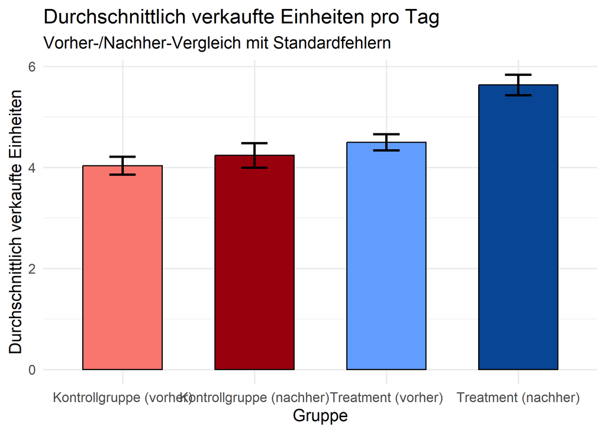

**Beschreibung:**

Das Balkendiagramm visualisiert, wie sich die durchschnittlich verkauften Einheiten pro Tag vor und nach der Kostentransparenzmaßnahme verändert haben. Die Grafik zeigt vier Balken - je einer für die Kontroll- bzw. Treatmentgruppe vor der Transparenzmaßnahme und je einer für die Kontroll- und Treatmentgruppe nach Einführung der Kostentransparenz. Die Fehlerbalken bzw. Standardfehler zeigen, wie präzise die Mittelwerte geschätzt wurden und auf der y-Achse ist die Anzahl der durchschnittlich verkauften Einheiten pro Tag aufgelistet. Man kann erkennen, dass sich die durchschnittlich verkauften Einheiten pro Tag vor der Einführung der Kostentransparenzmaßnahme nicht groß unterschieden haben. In der Kontrollgruppe waren dies rund 4 Einheiten pro Tag, in der Treatmentgruppe rund 4,5 Einheiten pro Tag. Nach dem Treatment lässt sich ein anderes Bild feststellen: Während sich die Verkaufszahlen in der Kontrollgruppe von 4 auf etwa 4,2 verändert haben, lässt sich in der Treatmentgruppe ein Anstieg von zuvor 4,5 auf etwa 5,6 erkennen.

**Interpretation:**

Da sich die Verkaufszahlen in der Kontrollgruppe kaum verändert haben, während sie in der Treatmentgruppe um mehr als eine Einheit gestiegen sind, spricht dies für eine Wirkung der Kostentransparenzmaßnahme. Die Differenz deutet darauf hin, dass nicht ein allgemeiner Trend die Verkaufszahlen hat steigen lassen, sondern speziell die Kostentransparenzmaßnahme zu einem Verkaufsanstieg beigetragen haben könnte. Im Sinne des DiD-Ansatzes ist die unterschiedliche Entwicklung der beiden Gruppen relevant. Sofern beide Gruppen vor der Einführung der Maßnahme einem ähnlichen Trend gefolgt sind, was hier durch die sehr ähnliche Verkaufszahlen vor der Treatmenteinführung der Fall war, deutet der beobachtete Unterschied darauf hin, dass der Anstieg in der Treatmentgruppe auf die Kostentreansparenz zurückzuführen sind. Diese Beobachtung spricht somit für einen möglichen kausalen Effekt des natürlichen Experiments auf das Verkaufsverhalten.

22. In der vorherigen Aufgabe haben Sie den Effekt von Kostentransparenz auf die Verkaufszahlen anhand eines deskriptiven Vergleichs untersucht. Dabei haben Sie die durchschnittlich täglich verkauften Einheiten je Treatment vor und nach der Einführung der Transparenzmaßnahme grafisch gegenübergestellt. In dieser Aufgabe sollen Sie diesen Effekt nun ökonometrisch genauer untersuchen, indem Sie den Difference-in-Differences Ansatz in einem Regressionsrahmen anwenden.

Untersuchen Sie den Effekt der Einführung von Kostentransparenz auf die Verkaufszahlen mithilfe einer Difference-in-Differences Regression. Verwenden Sie hierfür Beobachtungen an Werktagen, sowie am Wochenende (Montag bis Sonntag), mit positiven Verkaufszahlen.

Erstellen Sie insgesamt zwei Regressionsmodelle:

- Basismodell ohne Kontrollvariablen
- Modell mit Kontrolle für Wochentagseffekte

Stellen Sie die Ergebnisse anschaulich dar. Beschreiben und interpretieren Sie Ihre Ergebnisse. Gehen Sie insbesondere auf folgende Aspekte ein.

- Wie würden Sie die Größe des Effekts interpretieren, den Sie für `treated:post` erhalten haben?
- Welche Vorteile bringt es, log_units (logarithmierte Verkäufe) als abhängige Variable zu verwenden?
- Können Sie aus Ihrer Schätzung auf einen kausalen Effekt der Kostentransparenz schließen?
- Inwiefern hilft die Kontrolle für Wochentage dabei, Verzerrungen in der Schätzung zu vermeiden?
- Würden Sie auf Basis Ihrer Analyse eine Empfehlung zur Beibehaltung oder Ausweitung der Kostentransparenz geben?
- Worin könnten ihrer Ansicht nach Probleme liegen bei der Betrachtung eines natürlichen Experiments, die die Ergebnisse verzerren könnten?

*Hinweis 1:* Nutzen Sie für die Schätzung die `feols()`-Funktion aus dem fixest-Paket.

*Hinweis 2:* Nutzen Sie die logarithmierten täglichen Verkaufszahlen als abhängige Variable.

|  | Ohne Wochentagseffekte | Mit Wochentagseffekten |
| --- | --- | --- |
| Intercept | 1.285*** | 1.284*** |
|  | (<0.001) | (<0.001) |
| Treatmentgruppe | 0.105+ | 0.106+ |
|  | (0.094) | (0.089) |
| Nach Einführung | 0.066 | 0.064 |
|  | (0.395) | (0.403) |
| DiD-Effekt | 0.182+ | 0.182+ |
|  | (0.068) | (0.066) |
| Num.Obs. | 470 | 470 |
| R2 | 0.060 | 0.081 |
| R2 Adj. | 0.054 | 0.063 |
| Std.Errors | IID | IID |

+ p < 0.1, * p < 0.05, ** p < 0.01, *** p < 0.001

**Beschreibung:**

Bei der durchgeführten Regression handelt es sich um eine Difference-in-Differences-Analyse, mit der untersucht wird, wie sich die Einführung der Kostentransparenz auf die Verkaufszahlen ausgewirkt hat. Dabei wird der Unterschied in den Verkaufszahlen zwischen der Gruppe mit Kostentransparenz und der Kontrollgruppe vor und nach der Einführung der Maßnahme verglichen. Als abhängige Variable wurden die logarithmierten täglichen Verkaufszahlen verwendet, um prozentuale Effekte modellieren zu können und Ausreißer zu reduzieren. Die Regression schätzt insbesondere den DiD-Effekt, also die Veränderung der Verkaufszahlen, die auf die Maßnahme Kostentransparenz zurückzuführen ist. Die Ergebnisse zeigen, dass die Kostentransparenz mit einem positiven Effekt auf die Verkaufszahlen verbunden ist. Die Verkaufszahlen in der Treatmentgruppe sind nach der Einführung der Kostentransparenzmaßnahme gestiegen. Diese positive Effekt bleibt auch bestehen, wenn Wochentagseffekte kontrolliert werden.

**Interpretation:**

Die Ergebnisse der DiD-Regression zeigen, dass der Interaktionsterm treatet:post, der den kausalen Effekt der Kostentransparenzmaßnahme auf die Verkaufszahlen in der Treatmentgruppe nach dessen Einführung misst, in beiden Modellen positiv und schwach signifikant ist. Der geschätzte Koeffizient beträgt 0.182, was auf einen Anstieg der logarithmierten Verkaufszahlen in der Treatmentgruppe nach Einführung der Kostentransparenzmaßnahme hindeutet. Da die abhängige Variable logarithmiert ist, kann der Effekt als prozentuale Veränderung interpretiert werden. Der Koeffizient von 0.182 entspricht einem Anstieg von ca. 20% (exp(0.182)) in den täglichen Verkaufszahlen der Treatmentgruppe nach Einführung der Kostentransparenz.

Die Verwendung der logarithmierten Einheiten als abhängige Variable hilft dabei, Ausreißer und starke Rechtsschiefe in den Verteilungen abzumildern und hilft außerdem bei der Interpretation. Die Koeffizienten lassen sich als prozentuale Effekte interpretieren, was oftmals anschaulicher ist.

Der DiD-Ansatz ist ein gutes Werkzeug zur kausalen Inferenz. Seine Validität hängt maßgeblich von der Paralleltrendentwicklung der Gruppen vor der Intervention ab. Da sich die Treatment und Kontrollgruppe hier nur um durchschnittlich etwa 0.5 Einheiten pro Tag unterscheiden, kann diese Paralleltrendentwicklung als gegeben angenommen werden, wodurch man den Effekt als kausal interpretieren kann. Um sich hier aber ganz sicher zu sein, sollte dies auch statistisch überprüft werden mit weiteren Tests und mögliche Verzerrungen wie Werbung oder ähnliches ausgeschlossen werden.

Das zweite Modell berücksichtigt zusätzlich Wochentagseffekte, was wichtig ist, da sich das Kaufverhalten je nach Wochentag unterscheiden kann. So gibt es sonntags bspw. weniger Einkäufe als unter der Woche. Die Kontrolle verhindert, dass solche Schwankungen fälschlicherweise als Effekt der Kostentransparenz gewertet werden. Durch das leicht höhere Bestimmtheitsmaß im Modell mit Berücksichtigung von Wochentagen deutet dies auf eine bessere Modellanpassung hin.

Auf Basis der festgestellten Ergebnisse scheint die Einführung von Kostentransparenz einen positiven Effekt auf die Verkaufszahlen gehabt zu haben. Auch wenn die Signifikanz nur schwach ist, spricht der Richtungskoeffizient von rund 20% für eine positive wirtschaftliche Wirkung. Eine Beibehaltung oder gezielte Ausweitung der Maßnahme könnte sich lohnen, insbesondere wenn weitere Analysen oder Folgeexperimente diesen Effekt bestätigen.

Trotz des Ansatzes gibt es potenzielle Verzerrungsquellen. Es könnte bspw. unbeobachtete Zeitfaktoren gegeben haben wie Werbung oder Saisonalität, die zeitgleich zur Transparenzmaßnahme stattgefunden haben. Außerdem könnten sich auch Messfehler oder nicht berücksichtige externe Ereignisse, wie die allgemeine Wirtschaftslage etc. auf das Kaufverhalten auswirken.

# Literatur

Mohan, B., Buell, R. W., & John, L. K. (2020). Lifting the veil: The benefits of cost transparency. Marketing Science, 39(6), 1105-1121. https://doi.org/10.1287/mksc.2019.1200

# Anhang

## Mediator

Im Rahmen von Mediationen ist der Mediator eine Variable, die den erklärenden Zusammenhang zwischen einer unabhängigen und einer abhängigen Variable vermittelt. Dabei wird untersucht, inwieweit der Einfluss der unabhängigen Variablen (z.B. Kostentransparenz) auf die abhängige Variable (z.B. Kaufabsicht) über einen vermittelnden Mechanismus - wie das Vertrauen der Kunden - erfolgt.

1. **Mediatoreffekt**: Der Mediatoren-Effekt, oft als ACME (Average Causal Mediation Effect) bezeichnet, beschreibt den indirekten Effekt, den die unabhängige Variable auf die abhängige Variable über den Mediator ausübt. Ist dieser Effekt signifikant, signalisiert dies, dass ein wesentlicher Teil des gesamten Einflusses über den vermittelnden Mechanismus läuft. Gleichzeitig kann ein nicht-signifikanter direkter Effekt (ADE - Average Direct Effect) darauf hindeuten, dass der Mediator den hauptsächlichen Erklärungsmechanismus darstellt.
2. **Funktion und Wirkung des Mediators**: Analog zum Konzept der signalgebenden Funktion bei Statussymbolen - deren Wert unter anderem von der Exklusivität und dem sozialen Kontext abhängt - fungiert der Mediator als vermittelnder Kanal, der erklärt, wie und warum der ursprüngliche Zusammenhang zwischen zwei Variablen zustande kommt. Der Mediator „überträgt“ quasi den Effekt der unabhängigen Variable auf die abhängige Variable. Dadurch kann in Modellen, in denen der direkte Zusammenhang zwischen der unabhängigen und der abhängigen Variable durch die Einbeziehung des Mediators verschwindet oder abgeschwächt wird, abgeleitet werden, dass der Mechanismus über den Mediator läuft. Dies ermöglicht ein tieferes Verständnis der zugrundeliegenden psychologischen Prozesse - etwa wie das Vertrauen der Kunden die Wirkung von Kostentransparenz auf deren Kaufabsicht vermittelt.

Zusammengefasst spielt der Mediator eine zentrale Rolle bei der Aufklärung der kausalen Mechanismen, indem er als vermittelnder Faktor zwischen Ursache und Wirkung identifiziert wird. Die signifikante Vermittlung über den Mediator zeigt, dass nicht allein das Vorhandensein von Kostentransparenz entscheidend ist, sondern auch, inwiefern diese Transparenz das Vertrauen stärkt - was wiederum maßgeblich die Kaufabsicht beeinflusst. So liefert die Mediationsanalyse wertvolle Einsichten, die über einfache bivariate Zusammenhänge hinausgehen und die Komplexität kausaler Mechanismen innerhalb von sozialen oder marktorientierten Prozessen sichtbar machen.